# MPG Estimation

The following notebook creates a model to estimate MPG of vehicles given the dataset shown below. This was completed as part of my coursework for Johns Hopkins University. Several pieces of code are provided by the instructors, and credit is attributed to them below.

```python
%matplotlib inline
```

```python
import numpy as np
import time
import seaborn as sns
import matplotlib.pyplot as plt
import scipy.stats as stats
import pandas as pd

sns.set(style="whitegrid")

# You may load the dataset from URL (instead of the local file) if you wish
auto_mpg_data = "https://raw.githubusercontent.com/fundamentals-of-data-science/datasets/master/auto-mpg.data.txt"
auto_mpg_names = "https://raw.githubusercontent.com/fundamentals-of-data-science/datasets/master/auto-mpg.names.txt"
```

# Problem Set 5

## Directions

1. Show all work/steps/calculations using a combination of code and Markdown. You will submit only this notebook named: [jhed_id].ipynb back to Blackboard from whence you downloaded it. Do not return the data to me.
2. **All** work is to be your own. This is not a group project. You may, however, use code from the lectures and labs. Provide citations for any code that is not your own. You may also consult Stackoverflow, etc. This is not by any means "closed book" or anything like that. Basically, I need to see if *you* learned the concepts from the Lectures, *Fundamentals*, and Labs.
3. Add whatever markdown or code cells you need in each part to explain and calculate your answers. Don't just provide answers but explain them as well. **Explain and interpret your results.**

## Introduction

Labs 9 and 10 were all about linear models, specifically linear and logistic regression. We learned how to build and interpret multivariate models by using domain knowledge, comparing the predicted and actual values of the coefficients and the credible intervals, and looking at residuals. We also applied transformations to make the models perform better and increase interpretability.

Using the techniques covered during Modules 9 and 10 (lectures, labs, course notes), **build, describe, and use** a linear regression model that estimates the target variable `mpg` for the accompanying auto data set. You may use other techniques you know but you must at least use the techniques described in class and call out and describe anything "extra" that you do and why.

Do **not** use any feature selection techniques or anything other than linear regression. Follow the method described in class.

The instructions say build, **describe, and use**. You must describe all aspects of your final model (all the parameters and metrics) and use it to predict one value as described in the course notes.

## 1.1 ETL

## 1.2 EDA

### Single Variable EDA

MPG  
Cylinders  
Displacement  
Horsepower  
Weight  
Acceleration  
Model Year  
Origin  
Car Name

### Pairwise EDA

MPG & Cylinders  
MPG & Displacement  
MPG & Horsepower  
MPG & Weight  
MPG & Acceleration  
MPG & Model Year  
MPG & Origin  
MPG & Car Name

### Build the Model

Model 1  
Model 2  
Model 3  
Model 4  
Model 5  
Model 6  
Model 7  
Model 8

### Describe the Model

Description of Coefficients  
Cross Validation  
Learning Curves

## 1.1 - ETL

We begin by loading the data.

```python
import re

file = open('auto-mpg.data.txt', "r")
lines = file.readlines()

mpg = []
cylinders = []
displacement = []
horsepower = []
weight = []
acceleration = []
model_year = []
origin = []
car_name = []

columns = [mpg, cylinders, displacement, horsepower, weight, acceleration, model_year, origin, car_name]

for line in lines:
    #next 3 lines format the name of the car
    line = line.replace('\t','    ')
    line = line.replace('\n','')
    line = line.replace('"','')
    dataValues = re.split('\s{2,}', line) # all values have at least 2 spaces between them (car names have 1 space in the name)
    for index, val in enumerate(dataValues):
        columns[index].append(val)
```

From reading the "names" file, we see the nine attributes of mpg, cylinders, displacement, horsepower, weight, acceleration, model year, origin, and the name of the car. We can use this information to parse the lines of the real data in the other .txt file.

```python
carsDict = {'mpg' : columns[0],
            'cylinders' : columns[1],
            'displacement' : columns[2],
            'horsepower' : columns[3],
            'weight' : columns[4],
            'acceleration' : columns[5],
            'model_year' : columns[6],
            'origin' : columns[7],
            'car_name' : columns[8]
            }
cars = pd.DataFrame(carsDict)
```

Let's take a look at the data and see if any more ETL needs to be performed:

```python
cars.info()
```

```
<class 'pandas.core.frame.DataFrame'>
RangeIndex: 398 entries, 0 to 397
Data columns (total 9 columns):
 #   Column        Non-Null Count  Dtype
---  ------        --------------  -----
 0   mpg           398 non-null    object
 1   cylinders     398 non-null    object
 2   displacement  398 non-null    object
 3   horsepower    398 non-null    object
 4   weight        398 non-null    object
 5   acceleration  398 non-null    object
 6   model_year    398 non-null    object
 7   origin        398 non-null    object
 8   car_name      398 non-null    object
dtypes: object(9)
memory usage: 14.1+ KB
```

There are 398 values for all variables, however, all of our data was loaded as strings - we'll need to convert to number types to be useful. In addition, we happen to conveniently know from our provided description that 6 values of "horsepower" are missing and replaced with '?'. What we choose to do is see if one of the other variables will be a good predictor for horsepower.

```python
tempCars = cars[cars.horsepower != '?']
tempCars = tempCars.reset_index()
for col in tempCars.columns[:-1]:
    tempCars.loc[:,col] = pd.to_numeric(tempCars[col])
```

We have converted a copy of our data to numerical quantities so that we may find the highest correlated variable:

```python
correlations = {}
for var in tempCars.columns[:-2]:
    correlationValue = stats.pearsonr(tempCars.horsepower, tempCars[var])[0]
    correlations[correlationValue] = var

highestCorrelationValue = sorted(correlations.keys())[-2] #second highest because horsepower is most correlated with itself
print(correlations[highestCorrelationValue], ":", highestCorrelationValue)
```

```
displacement : 0.8972570018434688
```

We see that displacement is highly correlated with horsepower, and so we shall just use this variable to build a quick model for the missing horsepower values.

```python
import models
```

```python
hp_model = 'horsepower ~ displacement'
hp_result = models.bootstrap_linear_regression(hp_model, data=tempCars)
models.describe_bootstrap_lr(hp_result)
```

| Linear Regression Results |  |  |  |
| --- | --- | --- | --- |
| $\theta$ |  | 95% BCI |  |
| ($\beta_0$) | 40.31 | (37.37, 43.57) |  |
| displacement ($\beta_1$) | 0.33 | (0.31, 0.34) |  |
| Metrics |  |  |  |
| $\sigma$ | 17.02 | (15.45, 18.29) |  |
| $R^2$ | 0.81 | (0.77, 0.84) |  |

With an $R^2$ of 0.81, we decide that this model is good enough to use to account for our missing values of horsepower, rather than getting rid of those 6 rows of data.

```python
beta0 = hp_result['coefficients'][0]
beta1 = hp_result['coefficients'][1]

for i in range(len(cars)):
    if cars.iloc[i].horsepower == '?':
        cars.iloc[i].horsepower = beta0 + beta1*float(cars.iloc[i][correlations[highestCorrelationValue]])
```

We have finally accounted for our missing horsepower values, and can now cast the rest of the data to numerical types.

```python
for col in cars.columns[:-1]:
    cars[col] = pd.to_numeric(cars[col])
```

```python
cars.info()
```

```
<class 'pandas.core.frame.DataFrame'>
RangeIndex: 398 entries, 0 to 397
Data columns (total 9 columns):
 #   Column        Non-Null Count  Dtype
---  ------        --------------  -----
 0   mpg           398 non-null    float64
 1   cylinders     398 non-null    int64
 2   displacement  398 non-null    float64
 3   horsepower    398 non-null    float64
 4   weight        398 non-null    float64
 5   acceleration  398 non-null    float64
 6   model_year    398 non-null    int64
 7   origin        398 non-null    int64
 8   car_name      398 non-null    object
dtypes: float64(5), int64(3), object(1)
memory usage: 26.5+ KB
```

Let's compare these data types to what we are told from the auto_mpg_names file:

Attribute Information:

```
1. mpg:           continuous
2. cylinders:     multi-valued discrete
3. displacement:  continuous
4. horsepower:    continuous
5. weight:        continuous
6. acceleration:  continuous
7. model year:    multi-valued discrete
8. origin:        multi-valued discrete
9. car name:      string (unique for each instance)
```

All of the data types seem to match up. Let's see if we are missing any other values that we were not told about.

```python
null_data = cars[cars.isnull().any(axis=1)]
null_data
```

|  | mpg | cylinders | displacement | horsepower | weight | acceleration | model_year | origin | car_name |
| --- | --- | --- | --- | --- | --- | --- | --- | --- | --- |

It seems most likely that the rest of our data is complete, however we shall of course keep an eye out for strange values during our EDA. Let's finally take a look at some values.

```python
cars.head()
```

|  | mpg | cylinders | displacement | horsepower | weight | acceleration | model_year | origin | car_name |
| --- | --- | --- | --- | --- | --- | --- | --- | --- | --- |
| 0 | 18.0 | 8 | 307.0 | 130.0 | 3504.0 | 12.0 | 70 | 1 | chevrolet chevelle malibu |
| 1 | 15.0 | 8 | 350.0 | 165.0 | 3693.0 | 11.5 | 70 | 1 | buick skylark 320 |
| 2 | 18.0 | 8 | 318.0 | 150.0 | 3436.0 | 11.0 | 70 | 1 | plymouth satellite |
| 3 | 16.0 | 8 | 304.0 | 150.0 | 3433.0 | 12.0 | 70 | 1 | amc rebel sst |
| 4 | 17.0 | 8 | 302.0 | 140.0 | 3449.0 | 10.5 | 70 | 1 | ford torino |

At this point we shall move on to EDA, knowing that what we discover here may lead us to backtrack and do a bit more ETL.

Back to Top

## 1.2 - EDA

We shall first perform single variable EDA on each of the nine variables, before moving on to pairwise EDA, focusing on how each variable relates to the target.

### Single Variable EDA

```python
mainColor = 'darkcyan'
secondColor = 'tomato'
```

```python
def histogram(data,column,bins=50,weights=None):
    figure = plt.figure(figsize=(10, 6))
    axes = figure.add_subplot(1, 1, 1)

    axes.set_xlabel(column)
    axes.set_ylabel("Count")

    axes.hist(data[column], bins=bins, color=mainColor,ec='black',weights=weights)
    axes.set_title("Count Histogram of " + column + "; " + str(bins) + " bins")
    axes.grid(zorder=0)

    plt.show()
    plt.close()
```

```python
from matplotlib.ticker import PercentFormatter as PF

def bars(data,column,rotation=0,normalize=False,defaultSort=True):
    counts = data[column].value_counts().sort_index()
    if defaultSort:
        proportions = data[column].value_counts(normalize=normalize).sort_index()*((100*normalize)+1-normalize)
    else:
        proportions = data[column].value_counts(normalize=normalize)*((100*normalize)+1-normalize)

    x = range(len(counts))
    width = 1/1.5

    figure = plt.figure(figsize=(10, 6))
    axes = figure.add_subplot(1, 1, 1)

    axes.bar(x, proportions, width, color=mainColor, align="center", ec='black')
    axes.set_xlabel(column)
    axes.set_xticks(x)
    axes.set_xticklabels(proportions.axes[0])

    if normalize:
        axes.set_ylabel("Percent")
        axes.yaxis.set_major_formatter(PF())
    else:
        axes.set_ylabel("Count")

        #     axes.xaxis.grid(False)
    plt.setp(axes.xaxis.get_majorticklabels(), rotation=rotation)
    axes.set_title("Relative Frequency of "+column)

    plt.show()
    plt.close()
```

```python
from matplotlib.ticker import PercentFormatter as PF

def hbars(data,column,rotation=0,normalize=False,defaultSort=True):
    counts = data[column].value_counts().sort_index()
    if defaultSort:
        proportions = data[column].value_counts(normalize=normalize).sort_index()*((100*normalize)+1-normalize)
    else:
        proportions = data[column].value_counts(normalize=normalize)*((100*normalize)+1-normalize)

    y = list(range(len(counts)))
    width = 1/1.5

    figure = plt.figure(figsize=(10, 8))
    axes = figure.add_subplot(1, 1, 1)

    axes.barh(y, proportions, width, color=mainColor, align="center", ec='black')
    axes.set_ylabel(column)
    axes.set_yticks(y)
    axes.set_yticklabels(proportions.axes[0])

    if normalize:
        axes.set_xlabel("Percent")
        axes.xaxis.set_major_formatter(PF())
    else:
        axes.set_xlabel("Count")

    plt.setp(axes.xaxis.get_majorticklabels(), rotation=rotation)
    axes.set_title("Relative Frequency of "+column)

    plt.show()
    plt.close()
```

#### MPG

We begin with mpg, or miles per gallon, our target variable. We are interested in eventually predicting how efficiently a car can use fuel given some other factors that we have.

```python
cars.mpg.describe()
```

```
count    398.000000
mean      23.514573
std        7.815984
min        9.000000
25%       17.500000
50%       23.000000
75%       29.000000
max       46.600000
Name: mpg, dtype: float64
```

The mean and median appear to be fairly close to one another suggesting the distribution of these values is fairly even, however it might have a slightly right skew since the mean is greater than the median. Let's visualize these values now.

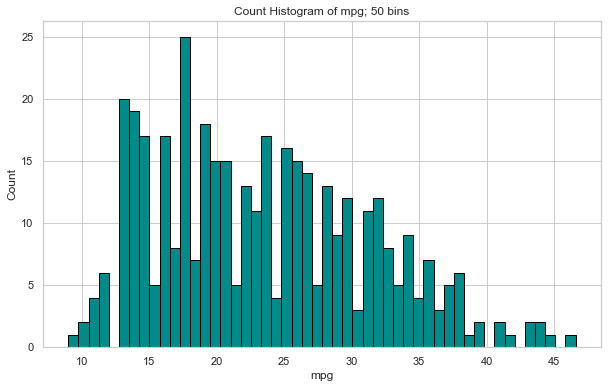

```python
histogram(cars,"mpg")
```

It appears as though there actually is a slight skew to the right, however the normal distribution does appear to be a decent model for this variable.

Back to Top

#### Cylinders

The cylinders of an engine is usually a proxy for essentially how big the engine is. Typical counts for the cylinders are 4, 6, or 8. We also know that these values are discrete and typically don't get higher than 16 (https://www.motor1.com/features/239145/most-powerful-engines-cylinders/#:~:text=16%20Cylinders%20%2D%20Bugatti%208.0%2DLiter,more%20cylinders%20than%20any%20other) and so we can treat this variable as discrete.

```python
cars.cylinders.value_counts(sort=False)
```

```
3      4
4    204
5      3
6     84
8    103
Name: cylinders, dtype: int64
```

We see that over half of the values are for 4 cylinder cars. Also note that due to how engines are made, it is far less common to have an odd number of cylinders (3 or 5) in the car. Let's see these on a chart.

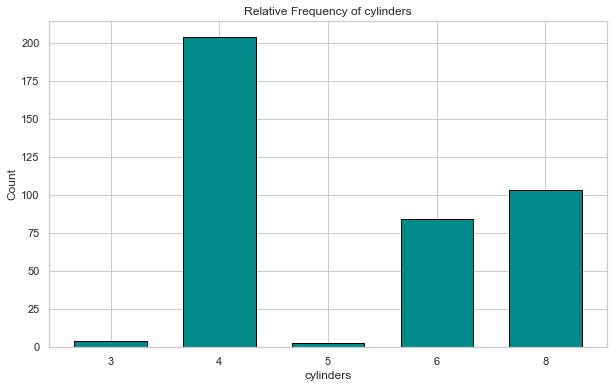

```python
bars(cars,"cylinders")
```

Back to Top

#### Displacement

This variable measures the combined volume of all of a car's cylinders, also known as the engine capacity. While not immediately relevant right now, we should note that this means there will be a high correlation between these displacement and cylinders when modeling later on.

```python
cars.displacement.describe()
```

```
count    398.000000
mean     193.425879
std      104.269838
min       68.000000
25%      104.250000
50%      148.500000
75%      262.000000
max      455.000000
Name: displacement, dtype: float64
```

Interestingly, we see a lot more variability in the displacement of a car than its cylinders, suggesting that the size of each cylinder can vary a lot. This suggests that displacement may be more informative than cylinders. It also brings up the possibility that creating a new feature like "cylinder_volume" could potentially be useful later as well. But for now, we shall visualize these values, noting that we also expect to see the values heavily skewed right judging by the mean and median values.

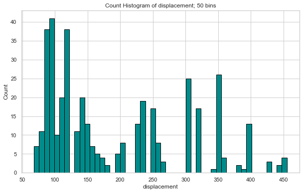

```python
histogram(cars,'displacement')
```

This data certainly does not look normally distributed, we may need to transform later when modeling.

Back to Top

#### Horsepower

A car's horsepower describes how much power the car has, and is another variable that is closely related to the engine of the car.

```python
cars.horsepower.describe()
```

```
count    398.000000
mean     104.143934
std       38.323493
min       46.000000
25%       75.000000
50%       92.000000
75%      125.000000
max      230.000000
Name: horsepower, dtype: float64
```

This data also looks skewed to the right, though we don't expect it to be normally distributed considering the shape of the displacement values. We also remember from our ETL that this variable has 6 values that were predicted from our displacement variable.

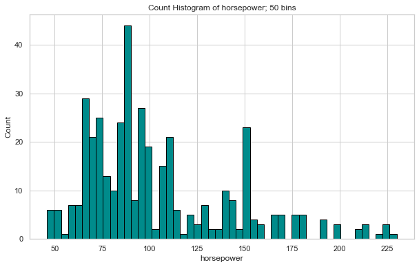

```python
histogram(cars,'horsepower')
```

This shape seems to remotely resemble our displacement variable with a longer tail to the right. This of course makes sense as the two are likely closely correlated, (which we will dive deeper into later).

Back to Top

#### Weight

The weight of the car is pretty self explanatory - how heavy is it (in pounds)?

```python
cars.weight.describe()
```

```
count     398.000000
mean     2970.424623
std       846.841774
min      1613.000000
25%      2223.750000
50%      2803.500000
75%      3608.000000
max      5140.000000
Name: weight, dtype: float64
```

We expect the values here to look a bit more like a normal distribution compared to previous variables, as weight is much more a measurement of many smaller additive factors.

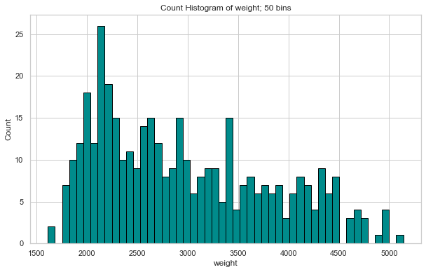

```python
histogram(cars,"weight")
```

Nope, the data here also appears rather skewed to the right (somewhat) similarly to the horsepower shape.

Back to Top

#### Acceleration

A car's acceleration is a measurement of the time (seconds) it takes for that vehicle to go from 0 mpg to 60mph.

```python
cars.acceleration.describe()
```

```
count    398.000000
mean      15.568090
std        2.757689
min        8.000000
25%       13.825000
50%       15.500000
75%       17.175000
max       24.800000
Name: acceleration, dtype: float64
```

This data likely won't have much skew judging by the closeness between the mean and median values. Would the normal distribution be a good fit?

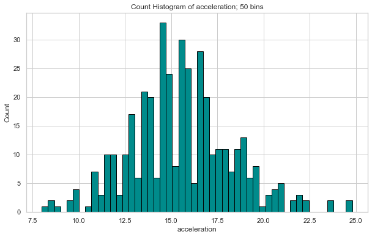

```python
histogram(cars,'acceleration')
```

A normal distribution does appear to be a decent fit here, though we do see some interesting peaks and valleys. Let's smooth it out by reducing the bins.

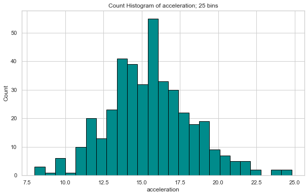

```python
histogram(cars,'acceleration', bins=25)
```

That looks much smoother.

Back to Top

#### Model Year

The model year is an indicator of how old the vehicle is. Later on we may likely want to create some additional features from this variable, likely by bucketing them into various groups.

```python
cars.model_year.describe()
```

```
count    398.000000
mean      76.010050
std        3.697627
min       70.000000
25%       73.000000
50%       76.000000
75%       79.000000
max       82.000000
Name: model_year, dtype: float64
```

The median value is "76" representing 1976. We also see that the range of years only goes from 1970 to 1982.

```python
len(cars.model_year.unique())
```

```
13
```

Indeed, with only 13 values we might be better off treating this variable as a categorical.

```python
cars.model_year.value_counts(sort=False)
```

```
70    29
71    28
72    28
73    40
74    27
75    30
76    34
77    28
78    36
79    29
80    29
81    29
82    31
Name: model_year, dtype: int64
```

It's a few too many values to make too much sense of without a chart.

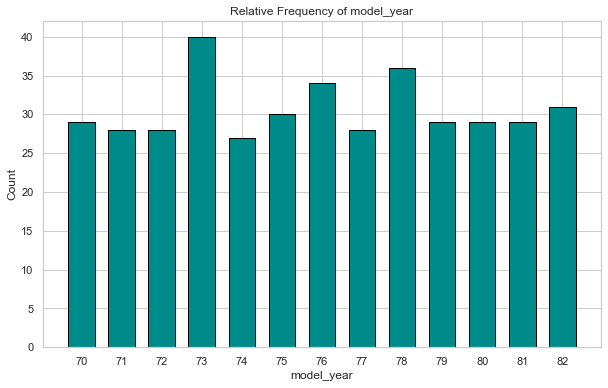

```python
bars(cars,'model_year')
```

It seems our model years are relatively uniform over the range.

Back to Top

#### Origin

Origin here refers to the country of origin that the car came from.

```python
cars.origin.value_counts()
```

```
1    249
3     79
2     70
Name: origin, dtype: int64
```

With only three values we can of course treat this as a categorical, but first, we need to figure out what country each number represents.

```python
cars[['origin','car_name']][cars.origin==1].head()
```

|  | origin | car_name |
| --- | --- | --- |
| 0 | 1 | chevrolet chevelle malibu |
| 1 | 1 | buick skylark 320 |
| 2 | 1 | plymouth satellite |
| 3 | 1 | amc rebel sst |
| 4 | 1 | ford torino |

Origin code 1 appears to be American manufacturers. 2?

```python
cars[['origin','car_name']][cars.origin==2].head()
```

|  | origin | car_name |
| --- | --- | --- |
| 19 | 2 | volkswagen 1131 deluxe sedan |
| 20 | 2 | peugeot 504 |
| 21 | 2 | audi 100 ls |
| 22 | 2 | saab 99e |
| 23 | 2 | bmw 2002 |

These are all European brands.

```python
cars[['origin','car_name']][cars.origin==3].head()
```

|  | origin | car_name |
| --- | --- | --- |
| 14 | 3 | toyota corona mark ii |
| 18 | 3 | datsun pl510 |
| 29 | 3 | datsun pl510 |
| 31 | 3 | toyota corona |
| 53 | 3 | toyota corolla 1200 |

Finally, origin code 3 looks to represent Japanese vehicles. Let's rename these to their more descriptive names.

```python
cars.loc[:, "origin"] = cars.origin.replace(1,'US')
cars.loc[:, "origin"] = cars.origin.replace(2,'Europe')
cars.loc[:, "origin"] = cars.origin.replace(3,'Japan')
```

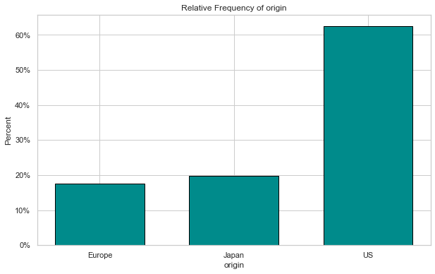

```python
bars(cars,'origin',normalize=True)
```

There are far more American made cars than those from either Europe or Japan.

Back to Top

#### Car Name

At first it seems as though there might not be much value in examining a car's name, however, perhaps some companies tend to make cars with a higher mpg. For this reason, let us at least extract the company name from the car name and create a new feature, company_name.

```python
cars["company_name"] = cars["car_name"].str.split(" ").str[0]
cars.head()
```

|  | mpg | cylinders | displacement | horsepower | weight | acceleration | model_year | origin | car_name | company_name |
| --- | --- | --- | --- | --- | --- | --- | --- | --- | --- | --- |
| 0 | 18.0 | 8 | 307.0 | 130.0 | 3504.0 | 12.0 | 70 | US | chevrolet chevelle malibu | chevrolet |
| 1 | 15.0 | 8 | 350.0 | 165.0 | 3693.0 | 11.5 | 70 | US | buick skylark 320 | buick |
| 2 | 18.0 | 8 | 318.0 | 150.0 | 3436.0 | 11.0 | 70 | US | plymouth satellite | plymouth |
| 3 | 16.0 | 8 | 304.0 | 150.0 | 3433.0 | 12.0 | 70 | US | amc rebel sst | amc |
| 4 | 17.0 | 8 | 302.0 | 140.0 | 3449.0 | 10.5 | 70 | US | ford torino | ford |

We are now of course probably back more in "ETL" territory, but let's inspect these company names a bit more.

```python
cars.company_name.unique()
```

```
array(['chevrolet', 'buick', 'plymouth', 'amc', 'ford', 'pontiac',
       'dodge', 'toyota', 'datsun', 'volkswagen', 'peugeot', 'audi',
       'saab', 'bmw', 'chevy', 'hi', 'mercury', 'opel', 'fiat',
       'oldsmobile', 'chrysler', 'mazda', 'volvo', 'renault', 'toyouta',
       'maxda', 'honda', 'subaru', 'chevroelt', 'capri', 'vw',
       'mercedes-benz', 'cadillac', 'mercedes', 'vokswagen', 'triumph',
       'nissan'], dtype=object)
```

We can see there are a few typos/abbreviations causing the same company to appear as though they are separate. Let's correct these manually:

```python
cars.loc[:, "company_name"] = cars.company_name.replace('chevy','chevrolet')
cars.loc[:, "company_name"] = cars.company_name.replace('chevroelt','chevrolet')
cars.loc[:, "company_name"] = cars.company_name.replace('maxda','mazda')
cars.loc[:, "company_name"] = cars.company_name.replace('toyouta','toyota')
cars.loc[:, "company_name"] = cars.company_name.replace('vw','volkswagen')
cars.loc[:, "company_name"] = cars.company_name.replace('vokswagen','volkswagen')
```

Let's see the names now:

```python
cars.company_name.unique()
```

```
array(['chevrolet', 'buick', 'plymouth', 'amc', 'ford', 'pontiac',
       'dodge', 'toyota', 'datsun', 'volkswagen', 'peugeot', 'audi',
       'saab', 'bmw', 'hi', 'mercury', 'opel', 'fiat', 'oldsmobile',
       'chrysler', 'mazda', 'volvo', 'renault', 'honda', 'subaru',
       'capri', 'mercedes-benz', 'cadillac', 'mercedes', 'triumph',
       'nissan'], dtype=object)
```

The one name that still seems strange is "hi", however

```python
cars[cars.company_name=='hi']
```

|  | mpg | cylinders | displacement | horsepower | weight | acceleration | model_year | origin | car_name | company_name |
| --- | --- | --- | --- | --- | --- | --- | --- | --- | --- | --- |
| 28 | 9.0 | 8 | 304.0 | 193.0 | 4732.0 | 18.5 | 70 | US | hi 1200d | hi |

A Google search suggests it is the "International Harvester" company https://www.carid.com/1970-international-1200d-body-parts/ and so we will leave this as is. We also note that this is the vehicle with the lowest mpg rating, (perhaps why the company is no longer in business).

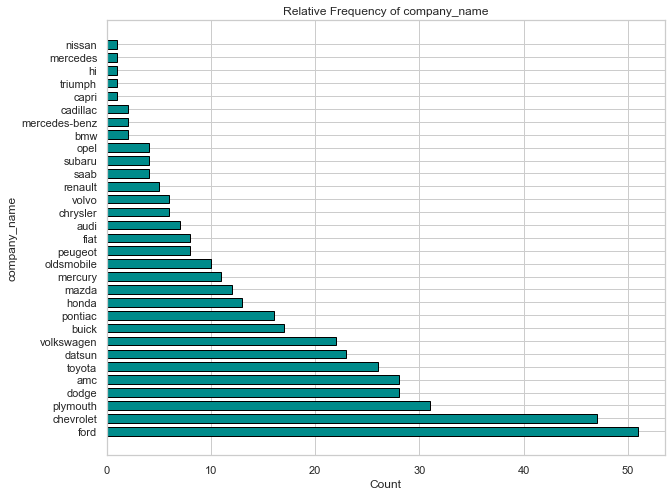

```python
hbars(cars,'company_name',defaultSort=False)
```

Ford and Chevrolet clearly have the most cars in this dataset.

Back to Top

### Pairwise EDA

We can now begin to look at our variables in relation to our target variable: mpg.

```python
# code adapted from course notes

def correlation(data, x, y):
    print("Correlation coefficients:")
    print( "r =", stats.pearsonr(data[x], data[y])[0])
    print( "rho =", stats.spearmanr(data[x], data[y])[0])
```

```python
# code adapted from course notes

def describeCategory(df, num, cat, trans=False):
    grouped = df.groupby(cat)
    groupedY = grouped[num].describe()
    if trans:
        print(groupedY.transpose())
    else:
        print(groupedY)
```

```python
def reorder(order, unsorted):
    zipped_lists = zip(order, unsorted)
    sorted_zipped_lists = sorted(zipped_lists)
    sorted_list = [element for _, element in sorted_zipped_lists]
    return sorted_list
```

```python
# code adapted from course notes

import eda as eda
def multiboxplot(data, numeric, categorical, width=10, skip_data_points=True, prefix='', vert=True, defaultSort=True):

    figure = plt.figure(figsize=(width, 6))

    axes = figure.add_subplot(1, 1, 1)

    grouped = data.groupby(categorical)
    labels = pd.unique(data[categorical].values)
    try:
        labels.sort()
    except:
        cat=True

    grouped_data = [grouped[numeric].get_group( k) for k in labels]
    if defaultSort:
        patch = axes.boxplot(grouped_data, labels=labels, patch_artist=True, zorder=1, vert=vert)
    else:

        mappings = [(x.median(),index) for index,x in enumerate(grouped_data)]
        map2 = list(range(len(mappings)))
        mappings.sort()
        indices = [x[1] for x in mappings]
        order = reorder(indices,map2)
        sorted_grouped_data = reorder(order,grouped_data)
        sorted_labels = reorder(order,labels)
        patch = axes.boxplot(sorted_grouped_data, labels=sorted_labels, patch_artist=True, zorder=1, vert=vert)

    eda.restyle_boxplot(patch)

    if not skip_data_points:
        for i, k in enumerate(labels):
            subdata = grouped[numeric].get_group( k)
            x = np.random.normal(i + 1, 0.01, size=len(subdata))
            axes.plot(x, subdata, 'o', alpha=0.4, color=mainColor, zorder=2)

    if vert==True:
        axes.set_xlabel(categorical)
        axes.set_ylabel(numeric)
    else:
        axes.set_ylabel(categorical)
        axes.set_xlabel(numeric)
    axes.set_title("{0}Distribution of {1} by {2}".format(prefix, numeric, categorical))

    plt.show()
    plt.close()
```

```python
# code adapted from course notes

def scatterJX(df,x,y,jitter=0,alpha=1):
    '''Scatter plot with jitter added on X Axis'''

    figure = plt.figure(figsize=(10, 6))
    axes = figure.add_subplot(1, 1, 1)

    originalX = df[x]
    np.random.seed(0)
    jitterX = originalX + stats.norm.rvs(0, jitter, originalX.size)

    axes.scatter(jitterX, df[y], marker="o", color=mainColor, alpha=alpha)

    if jitter!=0:
        suffix = ", (jitter added)"
    else:
        suffix = ""
    axes.set_title(y + " vs " + x + suffix)

    axes.set_xlabel(x)
    axes.set_ylabel(y)

    plt.show()
    plt.close()
```

```python
# code adapted from course notes

def scatterJY(df,x,y,jitter=0,alpha=1):
    '''Scatter plot with jitter added on Y Axis'''

    figure = plt.figure(figsize=(10, 6))
    axes = figure.add_subplot(1, 1, 1)

    originalY = df[y]
    np.random.seed(0)
    jitterY = originalY + stats.norm.rvs(0, jitter, originalY.size)

    axes.scatter(df[x], jitterY, marker="o", color=mainColor, alpha=alpha)

    if jitter!=0:
        suffix = ", (jitter added)"
    else:
        suffix = ""
    axes.set_title(y + " vs " + x + suffix)
    axes.set_xlabel(x)
    axes.set_ylabel(y)

    plt.show()
    plt.close()
```

#### MPG & Cylinders

We predict that there will be a fairly strong relationship between cylinders and MPG. Cylinders are essentially how big the engine of a car is. Larger engines mean bigger cars, which typically means less fuel efficiency, and so we expect to see a negative correlation.

```python
correlation(cars,'mpg','cylinders')
```

```
Correlation coefficients:
r = -0.7753962854205543
rho = -0.8218644914450965
```

```python
describeCategory(cars,'mpg','cylinders')
```

```
           count       mean       std   min    25%    50%    75%   max
cylinders
3            4.0  20.550000  2.564501  18.0  18.75  20.25  22.05  23.7
4          204.0  29.286765  5.710156  18.0  25.00  28.25  33.00  46.6
5            3.0  27.366667  8.228204  20.3  22.85  25.40  30.90  36.4
6           84.0  19.985714  3.807322  15.0  18.00  19.00  21.00  38.0
8          103.0  14.963107  2.836284   9.0  13.00  14.00  16.00  26.6
```

We see a little more detail here, and not too surprisingly note that the car with the worst fuel efficiency (9 mpg) is in the 8 cylinder category.

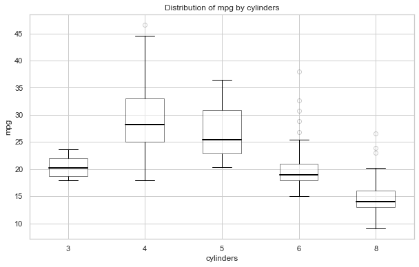

```python
multiboxplot(cars,'mpg','cylinders')
```

There definitely seems to be a downward trend in mpg as cylinders increase. Note that there are only 4 counts of 3 cylinder vehicles, explaining the slight departure from the rest of the pattern.

Back to Top

#### MPG & Displacement

We predict a similar trend here: as displacement of a car increases, mpg decreases.

```python
correlation(cars,'mpg','displacement')
```

```
Correlation coefficients:
r = -0.8042028248058979
rho = -0.8556920118178749
```

Pretty strong negative correlations.

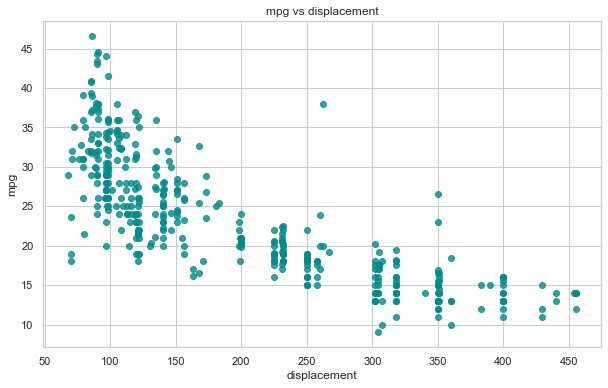

```python
scatterJX(cars,'displacement','mpg',alpha=0.8)
```

We see a fairly exponential looking distribution start to form. In fact, if we introduce a lot more noise in the form of "jitter", we can see the shape form even more:

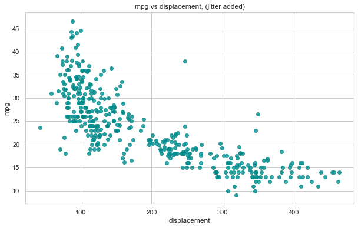

```python
scatterJX(cars,'displacement','mpg',alpha=0.8,jitter=10)
```

Adding some noise to the x axis actually helps us see a pattern a bit more clearly. There is one noticeable outlier around the 250 displacement mark.

```python
cars[(cars.displacement>200) & (cars.mpg>35)]
```

|  | mpg | cylinders | displacement | horsepower | weight | acceleration | model_year | origin | car_name | company_name |
| --- | --- | --- | --- | --- | --- | --- | --- | --- | --- | --- |
| 387 | 38.0 | 6 | 262.0 | 85.0 | 3015.0 | 17.0 | 82 | US | oldsmobile cutlass ciera (diesel) | oldsmobile |

This oldsmobile has a particularly high mpg rating for its displacement. According to https://www.aboutautomobile.com/Fuel-Economy/1982/Oldsmobile/Cutlass-Ciera however, this rating seems accurate.

Back to Top

#### MPG & Horsepower

We predict to once again see pretty strong negative correlations, as these variables are all likely well correlated with each other.

```python
correlation(cars,'mpg','horsepower')
```

```
Correlation coefficients:
r = -0.7774800678766243
rho = -0.8531523580368542
```

Indeed, we see similarly strong relations here.

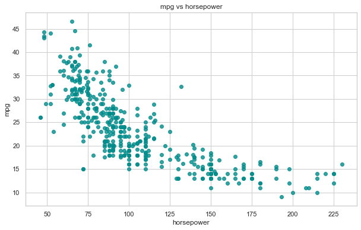

```python
scatterJX(cars,'horsepower','mpg',alpha=0.8)
```

We don't see any outliers particularly worthy of further investigation here, though there are of course a few. Instead we simply note the exponential pattern appearing once more.

Back to Top

#### MPG & Weight

We predict to perhaps see the strongest negative correlation yet with weight here, as the other variables were more of a proxy for how large a car is.

```python
correlation(cars,'mpg','weight')
```

```
Correlation coefficients:
r = -0.8317409332443348
rho = -0.8749473981990713
```

Indeed, these are the strongest correlation numbers yet.

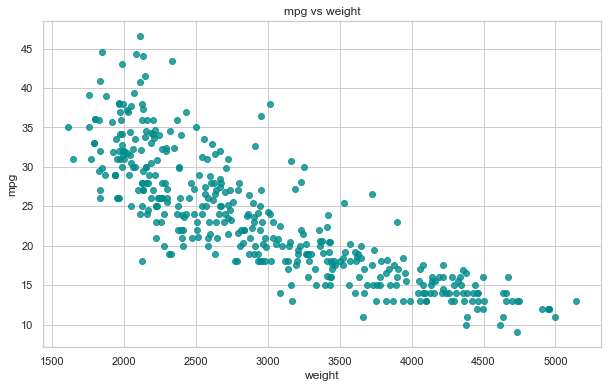

```python
scatterJX(cars,'weight','mpg',alpha=0.8)
```

We see a very similar shape forming once again.

Back to Top

#### MPG & Acceleration

Here we might expect to see a slightly weaker relationship between acceleration judging from our different acceleration chart relative to the other variables. We still expect to see a negative relation however, as increasing acceleration values here actually reflect *less* ability to accelerate and usually smaller cars can accelerate faster.

```python
correlation(cars,'mpg','acceleration')
```

```
Correlation coefficients:
r = 0.42028891210165054
rho = 0.4386774795708622
```

Interestingly, our prediction seemed quite incorrect in that the correlation is positive. However, we were correct to assume that the relationship would still be weaker. It seems that smaller cars also have smaller engines, decreasing their ability to quickly generate speed.

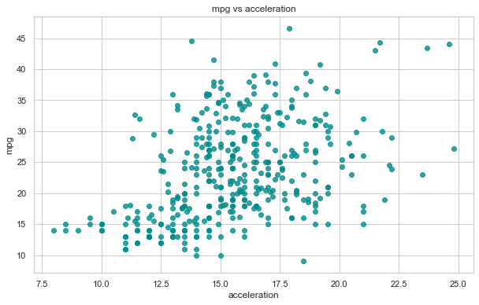

```python
scatterJX(cars,'acceleration','mpg',alpha=0.8)
```

It seems much more difficult at the moment to draw any conclusions about mpg given acceleration.

Back to Top

#### MPG & Model Year

We predict that newer cars will have better advances in technology that may improve gas mileage, indicating a postive correlation.

```python
correlation(cars,'mpg','model_year')
```

```
Correlation coefficients:
r = 0.5792671330833093
rho = 0.573468703192175
```

There does seem to be an increase in mpg as cars are made later.

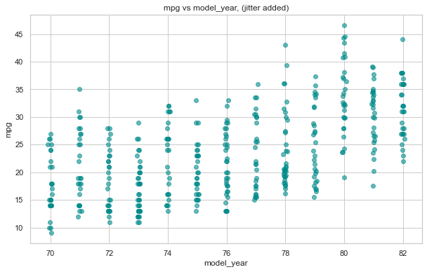

```python
scatterJX(cars,'model_year','mpg',alpha=0.6,jitter=0.03)
```

There certainly is an upward trend, however there is still a fair bit of noise we will need to deal with.

Back to Top

#### MPG & Origin

Our prediction is that cars from Europe and Japan will have better fuel efficiency than American cars. This may be a negative stereotype about Americans, let's see if it holds any weight:

```python
describeCategory(cars,'mpg','origin')
```

```
        count       mean       std   min   25%   50%    75%   max
origin
Europe   70.0  27.891429  6.723930  16.2  24.0  26.5  30.65  44.3
Japan    79.0  30.450633  6.090048  18.0  25.7  31.6  34.05  46.6
US      249.0  20.083534  6.402892   9.0  15.0  18.5  24.00  39.0
```

It does appear that US manufacturers are less concerned with fuel efficiency.

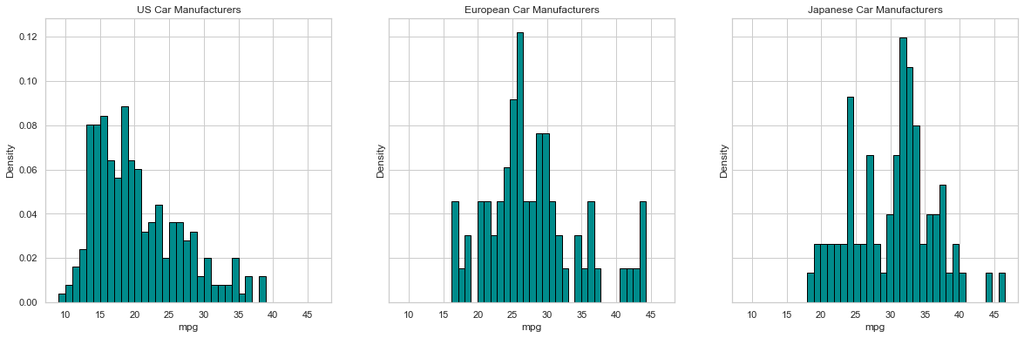

```python
fig, (ax1, ax2, ax3) = plt.subplots(figsize=(20,6),ncols=3, sharex=True, sharey=True)

x1 = cars[cars.origin=='US'].mpg
x2 = cars[cars.origin=='Europe'].mpg
x3 = cars[cars.origin=='Japan'].mpg

bins = 30

ax1.hist(x1, color=mainColor,ec='black',bins=bins,density=True)
ax1.set_xlabel("mpg")
ax1.set_ylabel("Density")
ax1.set_title("US Car Manufacturers")

ax2.hist(x2, color=mainColor,ec='black',bins=bins,density=True)
ax2.set_xlabel("mpg")
ax2.set_ylabel("Density")
ax2.set_title("European Car Manufacturers")

ax3.hist(x3, color=mainColor,ec='black',bins=bins,density=True)
ax3.set_xlabel("mpg")
ax3.set_ylabel("Density")
ax3.set_title("Japanese Car Manufacturers")


plt.show()
plt.close()
```

We clearly see the US distribution shifted far to the left relative to the other countries. The US almost looks like a truncated normal distribution, while the other two distributions somewhat resemble the normal distribution.

Back to Top

#### MPG & Car Name

We don't really have many predictions for which car names, (company names), will yield higher mpg results other than what we can tell from their country of origin.

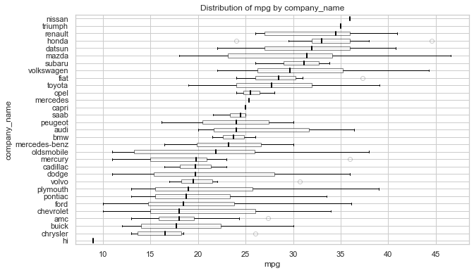

```python
multiboxplot(cars,'mpg','company_name',vert=False,defaultSort=False)
```

We have sorted the above companies by their median mpg. Of course, there are some companies with very few cars and others, (like Ford), which have a lot of cars in our dataset, so we should keep this in mind when drawing any conclusions from the chart.

Back to Top

## 1.3 - Build the model

```python
def createModel(features, df):
    model = 'mpg ~ ' + ' + '.join(features)
    result = models.bootstrap_linear_regression(model, data=df)

    return result
```

```python
# code adapted from course notes

def plotResiduals(result,features,df,labels=False):

    figure = plt.figure(figsize=(20,15))

    plots = len(features)
    rows = (plots // 2) + 1

    for index, feature in enumerate(features):
        axes = figure.add_subplot(rows, 2, index + 1)

        keyed_values = sorted(zip(df[feature].values, result["residuals"]), key=lambda x: x[0])
        residuals = [x[1][0] for x in keyed_values]

        if labels==True:
            axes.plot([x[0] for x in keyed_values], residuals, '.', color=mainColor, alpha=0.85)
        else:
            axes.plot(list(range(0, result["n"])), residuals, '.', color=mainColor, alpha=0.85)

        axes.axhline(y=0.0, xmin=0, xmax=result["n"], c="firebrick", alpha=0.6)
        axes.set_title(feature + " v. residuals")

    figure.tight_layout(pad=3.0)
    plt.show()
    plt.close()
```

```python
def color_negative_red(val):
    """
    Takes a scalar and returns a string with
    the css property `'color: red'` for negative
    strings, black otherwise.
    """
    color = 'red' if abs(val) > 0.8 else 'black'
    return 'color: %s' % color
```

```python
def correlationMatrix(features):
    '''
        Display the correlations between each feature in our model and return high correlations in red
    '''
    cols = []

    for col in features:
        rows = []
        for row in features:
            rows.append(stats.pearsonr(cars[row], cars[col])[0])
        cols.append(rows)

    df = pd.DataFrame(cols, columns = features, index=features)
    df = df.style.applymap(color_negative_red)

    return df
```

We now begin to build a linear model to estimate mpg. There are a few numerical variables that we may want to treat as categorical later, (namely cylinders and model_year), but for now we shall only create one hot encodings for the "origin" variable. Also, it seems at the moment like "origin" is at least as informative as "car_name" or "company_name" in a more succinct manner, so for now we shall not consider these name variables as features in our model.

```python
if cars.iloc[0].origin not in cars.columns: #if we re-run this code cell without restarting the whole notebook
    cars = pd.concat([cars, pd.get_dummies(cars["origin"])], axis=1)
```

We will assume that we want good base rate estimates, and so we shall drop the encoding with the highest observations for origin, which we saw earlier was 'US'. We first summarize our predictions based on what our EDA showed:

| Variable | Prediction |
| --- | --- |
| cylinders | negative |
| displacement | negative |
| horsepower | negative |
| weight | negative |
| acceleration | positive |
| model_year | positive |
| Europe | positive |
| Japan | positive |

Let's fit a model with all variables included, knowing that there is likely multicollinearity present.

### Model 1

```python
features1 = ['cylinders','displacement','horsepower','weight','acceleration','model_year','Europe','Japan']
result1 = createModel(features1,cars)
models.describe_bootstrap_lr(result1)
```

| Linear Regression Results |  |  |  |
| --- | --- | --- | --- |
| $\theta$ |  | 95% BCI |  |
| ($\beta_0$) | -18.15 | (-28.96, -8.12) |  |
| cylinders ($\beta_1$) | -0.43 | (-0.95, 0.20) |  |
| displacement ($\beta_2$) | 0.02 | (0.00, 0.04) |  |
| horsepower ($\beta_3$) | -0.02 | (-0.05, 0.01) |  |
| weight ($\beta_4$) | -0.01 | (-0.01, -0.01) |  |
| acceleration ($\beta_5$) | 0.08 | (-0.15, 0.31) |  |
| model_year ($\beta_6$) | 0.78 | (0.68, 0.88) |  |
| Europe ($\beta_7$) | 2.80 | (1.60, 3.77) |  |
| Japan ($\beta_8$) | 2.88 | (1.91, 3.94) |  |
| Metrics |  |  |  |
| $\sigma$ | 3.31 | (2.98, 3.56) |  |
| $R^2$ | 0.82 | (0.80, 0.86) |  |

```python
models.adjusted_r_squared(result1)
```

```
0.8202573595915061
```

We see an initial (adjusted) $R^2$ of 0.82 which seems quite good, especially for our first model. We also see that we have reduced $\sigma$ from 7.82 to 3.31. However, as predicted, there seem to be strong signs of multicollinearity. We suspected this from domain knowledge, and can see it in observing that many of the variables seem to have quite a weaker effect than we might have predicted. In addition, we think displacement should have a negative correlation, yet it was positive, (and did not include 0 in the 95% BCI). Let's see exactly which variables from our model are most highly correlated:

```python
correlationMatrix(features1)
```

|  | cylinders | displacement | horsepower | weight | acceleration | model_year | Europe | Japan |
| --- | --- | --- | --- | --- | --- | --- | --- | --- |
| cylinders | 1.000000 | 0.950721 | 0.843642 | 0.896017 | -0.505419 | -0.348746 | -0.352861 | -0.396479 |
| displacement | 0.950721 | 1.000000 | 0.897960 | 0.932824 | -0.543684 | -0.370164 | -0.373886 | -0.433505 |
| horsepower | 0.843642 | 0.897960 | 1.000000 | 0.864827 | -0.687384 | -0.415672 | -0.288016 | -0.316051 |
| weight | 0.896017 | 0.932824 | 0.864827 | 1.000000 | -0.417457 | -0.306564 | -0.298843 | -0.440817 |
| acceleration | -0.505419 | -0.543684 | -0.687384 | -0.417457 | 1.000000 | 0.288137 | 0.204473 | 0.109144 |
| model_year | -0.348746 | -0.370164 | -0.415672 | -0.306564 | 0.288137 | 1.000000 | -0.024489 | 0.193101 |
| Europe | -0.352861 | -0.373886 | -0.288016 | -0.298843 | 0.204473 | -0.024489 | 1.000000 | -0.229895 |
| Japan | -0.396479 | -0.433505 | -0.316051 | -0.440817 | 0.109144 | 0.193101 | -0.229895 | 1.000000 |

The values shown in red above represent those where there is a very strong correlation present (>0.8). Of course every feature has a perfect 1.0 correlation with itself which is not a concern, however, we see that cylinders, displacement, horsepower, and weight all have very strong correlations with one another, (the strongest of which is cylinders and displacement). Let's look at the residuals.

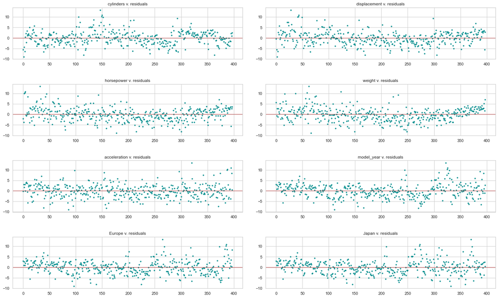

```python
plotResiduals(result1,features1,cars)
```

There don't appear to be many strikingly terrible patterns, but let's fit a model where we only look at the weight feature to eliminate our multicollinearity.

Back to Top

### Model 2

```python
features2 = ['weight','acceleration','model_year','Europe','Japan']
result2 = createModel(features2,cars)
models.describe_bootstrap_lr(result2)
```

| Linear Regression Results |  |  |  |
| --- | --- | --- | --- |
| $\theta$ |  | 95% BCI |  |
| ($\beta_0$) | -18.68 | (-27.71, -9.79) |  |
| weight ($\beta_1$) | -0.01 | (-0.01, -0.01) |  |
| acceleration ($\beta_2$) | 0.05 | (-0.09, 0.23) |  |
| model_year ($\beta_3$) | 0.76 | (0.66, 0.85) |  |
| Europe ($\beta_4$) | 2.08 | (0.94, 3.30) |  |
| Japan ($\beta_5$) | 2.25 | (1.31, 3.34) |  |
| Metrics |  |  |  |
| $\sigma$ | 3.34 | (3.00, 3.61) |  |
| $R^2$ | 0.82 | (0.79, 0.85) |  |

```python
models.adjusted_r_squared(result2)
```

```
0.8165166894741973
```

So we haven't changed our $R^2$, and $\sigma$ got a little worse. This is not too surprising though considering that all we did was remove variables. Our adjusted $R^2$ also took a very slight dip.

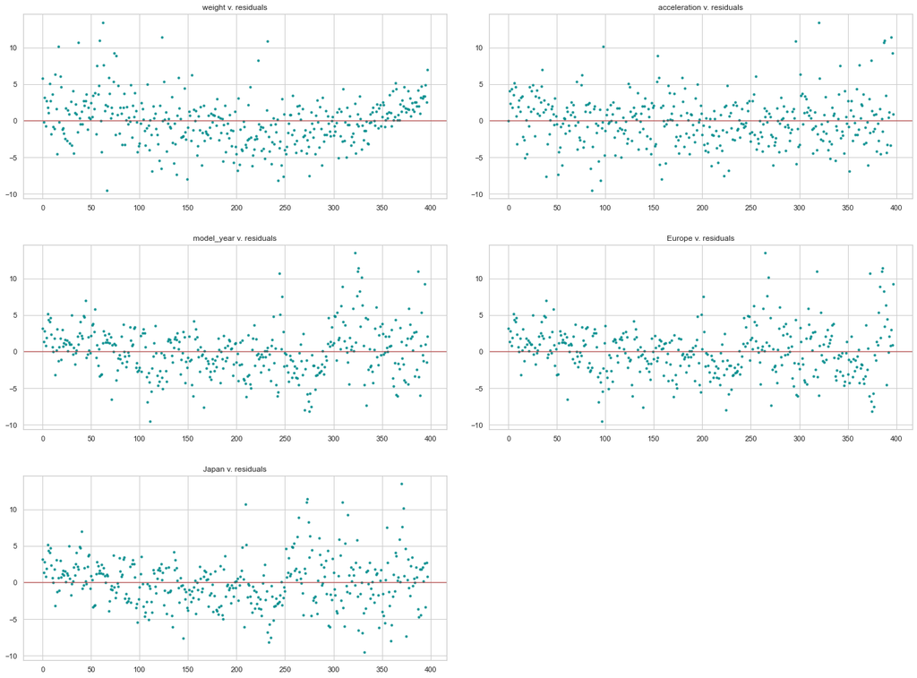

```python
plotResiduals(result2,features2,cars)
```

We see that the residuals for the weight feature have a curve to them that may be improved by raising the weight to some polynomial. Let's find out the best one.

Back to Top

### Model 3

```python
from collections import defaultdict
import random
import patsy
```

```python
# code adapted from course notes

def data_collection():
    result = dict()
    result[ "train"] = defaultdict( list)
    result[ "test"] = defaultdict( list)
    return result
```

```python
# code adapted from course notes

def chunk(xs, n):
    k, m = divmod(len(xs), n)
    return [xs[i * k + min(i, m):(i + 1) * k + min(i + 1, m)] for i in range(n)]
```

```python
# code adapted from course notes

def validation_curves(algorithm, formulas, data, values, evaluate, fold_count=10, repetitions=3, increment=1):
    indices = list(range(len( data)))
    results = data_collection()
    for _ in range(repetitions):
        random.shuffle(indices)
        folds = chunk(indices, fold_count)
        for fold in folds:
            test_data = data.iloc[ fold]
            train_indices = [idx for idx in indices if idx not in fold]
            train_data = data.iloc[train_indices]
            for i, p in enumerate(zip(formulas, values)):
                f, v = p
                # it's ok to resuse the folds for each v of values
                # we calculate the model
                result = algorithm(f, train_data, v)
                model = result["model"]
                # we calculate the results for the training data subset
                y, X = patsy.dmatrices(f, train_data, return_type="matrix")
                result = models.summarize(f, X, y, model)
                metric = evaluate(result)
                results["train"][i].append( metric)

                # we calculate the results for the test data.
                y, X = patsy.dmatrices(f, test_data, return_type="matrix")
                result = models.summarize(f, X, y, model)
                metric = evaluate(result)
                results["test"][i].append( metric)
            #
        #
    # process results
    # Rely on the CLT...
    statistics = {}
    for k, v in results["train"].items():
        statistics[ k] = (np.mean(v), np.std(v))
    results["train"] = statistics
    statistics = {}
    for k, v in results["test"].items():
        statistics[ k] = (np.mean(v), np.std(v))
    results["test"] = statistics
    return results
#
```

```python
# code adapted from course notes

def results_to_curves( curve, results):
    all_statistics = results[ curve]
    keys = list( all_statistics.keys())
    keys.sort()
    mean = []
    upper = []
    lower = []
    for k in keys:
        m, s = all_statistics[ k]
        mean.append( m)
        upper.append( m + 2 * s)
        lower.append( m - 2 * s)
    return keys, lower, mean, upper
```

```python
# code adapted from course notes

def plot_validation_curves( results, metric, parameter, values, zoom=False):
    figure = plt.figure(figsize=(10,6))

    axes = figure.add_subplot(1, 1, 1)

    xs, train_lower, train_mean, train_upper = results_to_curves( "train", results)
    _, test_lower, test_mean, test_upper = results_to_curves( "test", results)

    axes.plot( values, train_mean, color="steelblue")
    axes.fill_between( values, train_upper, train_lower, color="steelblue", alpha=0.25, label="train")
    axes.plot( values, test_mean, color="firebrick")
    axes.fill_between( values, test_upper, test_lower, color="firebrick", alpha=0.25, label="test")
    axes.legend()
    axes.set_xlabel( parameter)
    axes.set_ylabel( metric)
    axes.set_title("Validation Curves")

    if zoom:
        y_lower = int( 0.9 * np.amin([train_lower[-1], test_lower[-1]]))
        y_upper = int( 1.1 * np.amax([train_upper[-1], test_upper[-1]]))
        axes.set_ylim((y_lower, y_upper))

    plt.show()
    plt.close()
#
```

Let's start with degrees from 0.1 to 2.5.

```python
weights = [x / 10 for x in range(1, 26, 1)]
for w in weights:
    cars["weight_" + str(w).replace('.', '_')] = cars.weight ** w
```

```python
formulas = []
for w in weights:
    formula = 'mpg ~ acceleration + model_year + Europe + Japan'
    f = formula + " + weight_" + str(w).replace('.', '_')
    formulas.append(f)

def f(formula, data, v):
    return models.linear_regression(formula, data, style="linear")

weightValidation = validation_curves(f, formulas, cars, weights, lambda r: r["sigma"])
```

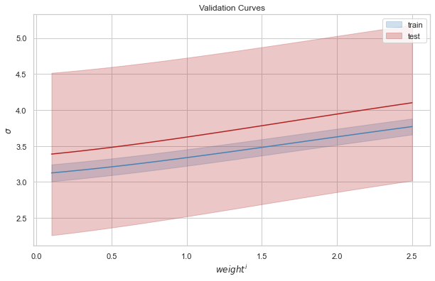

```python
plot_validation_curves(weightValidation, r"$\sigma$", r"$weight^i$", weights)
```

```python
def get_key(dictionary, val):
    for key, value in dictionary.items():
         if val == value:
            return key
```

```python
minError = min(weightValidation["test"].values())
position = get_key(weightValidation["test"], minError)
print("The lowest error is {} and comes at position {}.".format(minError[0],position))
```

```
The lowest error is 3.3876857229879334 and comes at position 0.
```

It seems that our error decreases as our polynomial degree does. Perhaps we could try negative values?

```python
weights = [x / 10 for x in range(-26, 26, 1)]
for w in weights:
    cars["weight_" + str(w).replace('.', '_').replace('-','N')] = cars.weight ** w
```

```python
formulas = []
for w in weights:
    formula = 'mpg ~ acceleration + model_year + Europe + Japan'
    f = formula + " + weight_" + str(w).replace('.', '_').replace('-','N')
    formulas.append(f)

def f(formula, data, v):
    return models.linear_regression(formula, data, style="linear")

weightValidation = validation_curves(f, formulas, cars, weights, lambda r: r["sigma"])
```

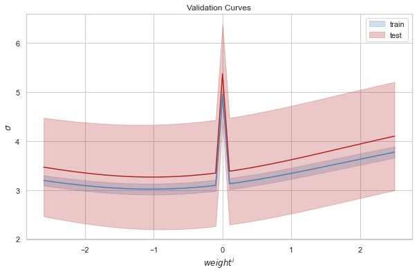

```python
plot_validation_curves(weightValidation, r"$\sigma$", r"$weight^i$", weights)
```

This is almost the exact inverse of what we want a validation curve to look like for $\sigma$! We have very clearly determined that the HIGHEST error comes when the weight is not raised to any polynomial.

```python
maxError = max(weightValidation["test"].values())
position = get_key(weightValidation["test"], maxError)
print("The highest error is {} and comes at position {}.".format(maxError[0],position))
```

```
The highest error is 5.368527803376329 and comes at position 26.
```

```python
weights[26]
```

```
0.0
```

Looking more closely at the validation curves however, we can actually find a minimum error as well. Let's find that exact value:

```python
minError = min(weightValidation["test"].values())
position = get_key(weightValidation["test"], minError)
print("The lowest error is {} and comes at position {}.".format(minError[0],position))
```

```
The lowest error is 3.262625595666323 and comes at position 16.
```

```python
weights[16]
```

```
-1.0
```

So it looks like taking the reciprocal of the weight leads to the lowest error. Let's move forward with this parameter in the model.

```python
features3 = ['weight_N1_0','acceleration','model_year','Europe','Japan']
result3 = createModel(features3,cars)
models.describe_bootstrap_lr(result3)
```

| Linear Regression Results |  |  |  |
| --- | --- | --- | --- |
| $\theta$ |  | 95% BCI |  |
| ($\beta_0$) | -59.87 | (-66.51, -53.51) |  |
| weight_N1_0 ($\beta_1$) | 53707.28 | (50311.60, 57234.81) |  |
| acceleration ($\beta_2$) | 0.08 | (-0.07, 0.21) |  |
| model_year ($\beta_3$) | 0.82 | (0.74, 0.90) |  |
| Europe ($\beta_4$) | 1.48 | (0.52, 2.65) |  |
| Japan ($\beta_5$) | 1.07 | (0.31, 1.98) |  |
| Metrics |  |  |  |
| $\sigma$ | 3.02 | (2.68, 3.29) |  |
| $R^2$ | 0.85 | (0.83, 0.88) |  |

```python
models.adjusted_r_squared(result3)
```

```
0.8501781077549984
```

So that gave a somewhat noticeable boost to both $R^2$ values as well as a slight improvement in $\sigma$. How are the residuals?

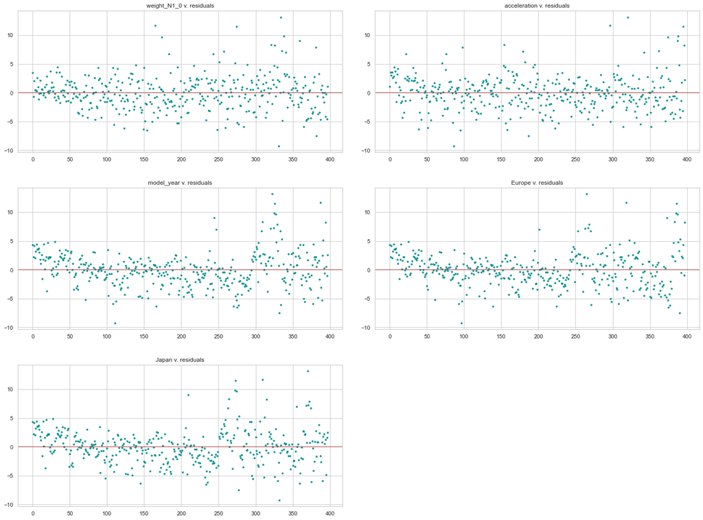

```python
plotResiduals(result3,features3,cars)
```

We seem to have eliminated the curve in the weight residuals, however, the model year residuals seem to show a similar pattern. Let's apply the same procedure to see if another polynomial would work better.

Back to Top

### Model 4

We try a slightly broader range of polynomials here.

```python
cars["years_after_1969"] = cars["model_year"] - 69 #help with interpretability
year_weights = [x / 10 for x in range(-26, 36, 1)]
for yw in year_weights:
    cars["post69_" + str(yw).replace('.', '_').replace('-','N')] = cars.years_after_1969 ** yw
```

Notice that we first created a new feature, "years_after_1969". It makes sense to scale the model_year in this way if we are to apply a polynomial to it. This way, differences in year can be more precisely measured.

```python
year_formulas = []
for yw in year_weights:
    formula = 'mpg ~ weight_N1_0 + acceleration + Europe + Japan'
    f = formula + " + post69_" + str(yw).replace('.', '_').replace('-','N')
    year_formulas.append(f)

def f(formula, data, v):
    return models.linear_regression(formula, data, style="linear")

yearValidation = validation_curves(f, year_formulas, cars, year_weights, lambda r: r["sigma"])
```

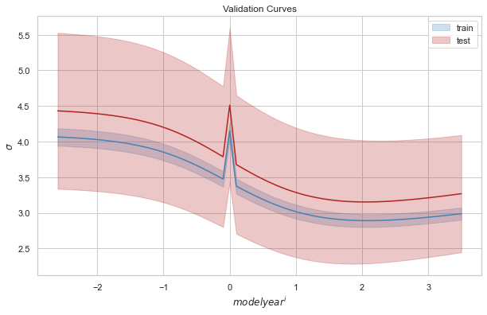

```python
plot_validation_curves(yearValidation, r"$\sigma$", r"$model year^i$", year_weights)
```

We see a very similar pattern to our weight validation curves where there is a clear peak in the worst error at the value we were using. The min value looks to be around the "2.0" mark.

```python
minError = min(yearValidation["test"].values())
position = get_key(yearValidation["test"], minError)
print("The lowest error is {} and comes at position {}.".format(minError[0],position))
```

```
The lowest error is 3.15224889217334 and comes at position 47.
```

```python
year_weights[47]
```

```
2.1
```

Actually it is 2.1. Let's see how this value performs in our model now.

```python
features4 = ['weight_N1_0','acceleration','post69_2_1','Europe','Japan']
result4 = createModel(features4,cars)
models.describe_bootstrap_lr(result4)
```

| Linear Regression Results |  |  |  |
| --- | --- | --- | --- |
| $\theta$ |  | 95% BCI |  |
| ($\beta_0$) | -1.31 | (-3.23, 0.50) |  |
| weight_N1_0 ($\beta_1$) | 52041.10 | (48927.05, 55391.81) |  |
| acceleration ($\beta_2$) | 0.11 | (-0.01, 0.24) |  |
| post69_2_1 ($\beta_3$) | 0.05 | (0.04, 0.05) |  |
| Europe ($\beta_4$) | 1.71 | (0.70, 2.57) |  |
| Japan ($\beta_5$) | 1.16 | (0.40, 2.08) |  |
| Metrics |  |  |  |
| $\sigma$ | 2.89 | (2.50, 3.30) |  |
| $R^2$ | 0.86 | (0.84, 0.89) |  |

```python
models.adjusted_r_squared(result4)
```

```
0.8624687376656217
```

Another slight improvement in both the error and $R^2$, and it looks like any improvements from here are going to be minimal. How are the residuals fairing?

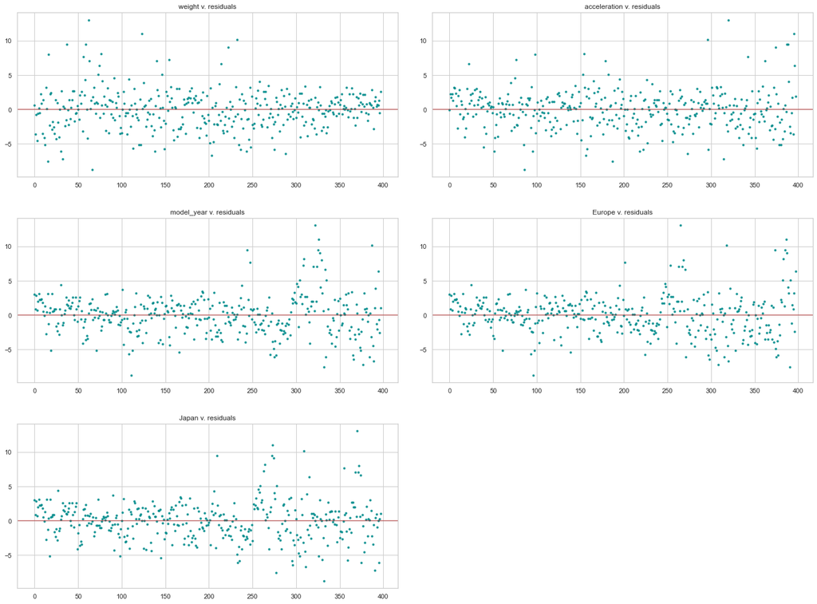

```python
plotResiduals(result4,features2,cars)
```

The model year residuals have slightly improved, however, there seems to be a lot more variability in the last quarter or so of the chart. Let's see exactly what year that corresponds to.

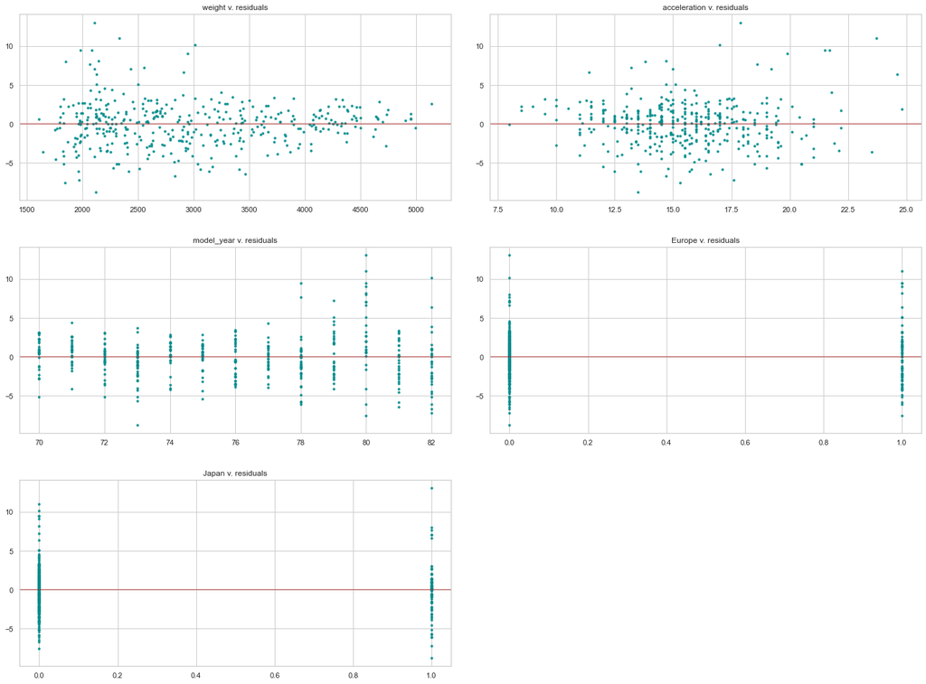

```python
plotResiduals(result4,features2,cars,labels=True)
```

After the year 1978, there is much more variability. This could very likely correspond to the Energy Policy and Conservation Act of 1975 which "established fuel economy standards for new passenger cars starting with model year (MY) 1978" https://www.ucsusa.org/resources/brief-history-us-fuel-efficiency#:~:text=Through%20the%20Energy%20Policy%20and,model%20year%20(MY)%201985

Let's reflect this in the next model.

Back to Top

### Model 5

```python
cars["modern"] = cars.model_year.apply(lambda x: 1 if x > 78 else 0) # 'modern' is used very loosely here
```

```python
features5 = ['weight_N1_0','acceleration','post69_2_1','Europe','Japan','modern']

result5 = createModel(features5,cars)
models.describe_bootstrap_lr(result5)
```

| Linear Regression Results |  |  |  |
| --- | --- | --- | --- |
| $\theta$ |  | 95% BCI |  |
| ($\beta_0$) | -1.08 | (-3.09, 0.69) |  |
| weight_N1_0 ($\beta_1$) | 51986.13 | (48108.23, 55932.60) |  |
| acceleration ($\beta_2$) | 0.12 | (-0.02, 0.24) |  |
| post69_2_1 ($\beta_3$) | 0.03 | (0.02, 0.04) |  |
| Europe ($\beta_4$) | 1.67 | (0.58, 2.75) |  |
| Japan ($\beta_5$) | 1.16 | (-0.06, 2.11) |  |
| modern ($\beta_6$) | 2.35 | (1.09, 3.58) |  |
| Metrics |  |  |  |
| $\sigma$ | 2.85 | (2.55, 3.11) |  |
| $R^2$ | 0.87 | (0.85, 0.90) |  |

```python
models.adjusted_r_squared(result5)
```

```
0.8667675642974434
```

Another little bump in our $R^2$. Note that the "modern" feature does indeed appear to be significant as we would predict that cars made after this year would have a positive effect on mpg.

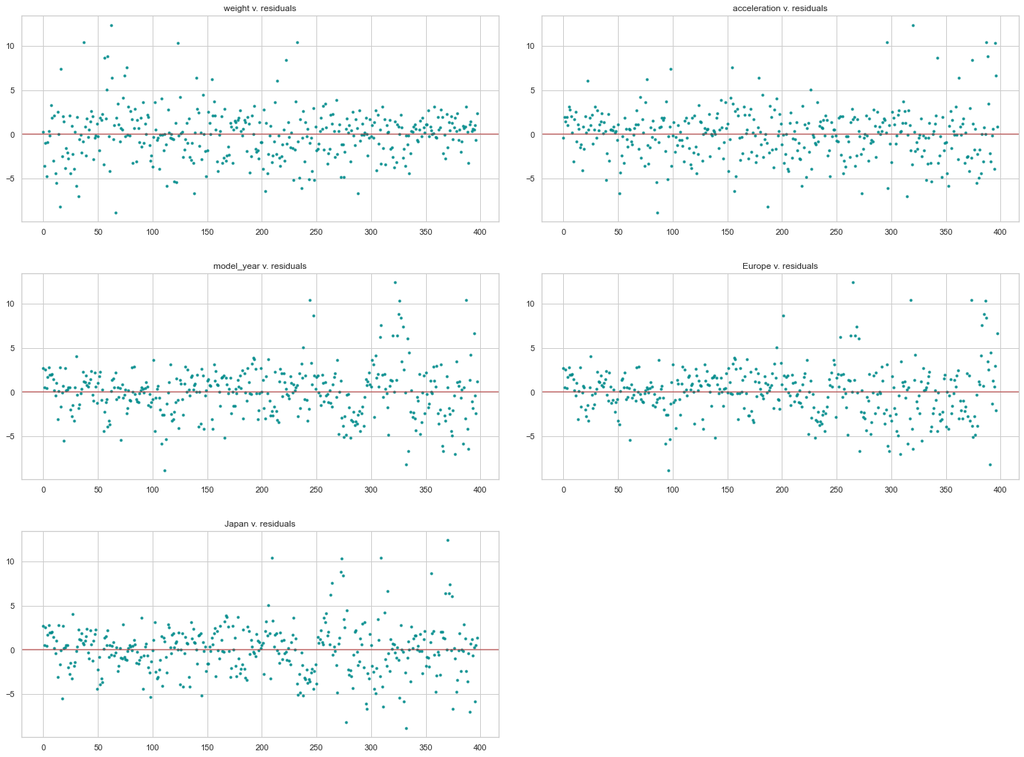

```python
plotResiduals(result5,features2,cars)
```

The residuals still appear to be a bit higher for "modern" cars. We also see more variability in both the Europe and Japan residuals. Considering that the Energy Policy and Conservation Act of 1975 was only enacted in the US, it makes sense that we should include "modern" interaction terms with these countries.

Back to Top

### Model 6

```python
features6 = ['weight_N1_0','acceleration','post69_2_1','Europe','Japan','modern','modern:Europe','modern:Japan']

result6 = createModel(features6,cars)
models.describe_bootstrap_lr(result6)
```

| Linear Regression Results |  |  |  |
| --- | --- | --- | --- |
| $\theta$ |  | 95% BCI |  |
| ($\beta_0$) | -1.03 | (-2.49, 0.66) |  |
| weight_N1_0 ($\beta_1$) | 54114.68 | (50170.84, 58071.69) |  |
| acceleration ($\beta_2$) | 0.10 | (-0.03, 0.20) |  |
| post69_2_1 ($\beta_3$) | 0.03 | (0.02, 0.04) |  |
| Europe ($\beta_4$) | 0.14 | (-0.77, 1.04) |  |
| Japan ($\beta_5$) | 0.18 | (-0.68, 1.33) |  |
| modern ($\beta_6$) | 0.79 | (-0.42, 2.19) |  |
| modern:Europe ($\beta_7$) | 5.02 | (2.44, 7.47) |  |
| modern:Japan ($\beta_8$) | 2.15 | (0.11, 4.13) |  |
| Metrics |  |  |  |
| $\sigma$ | 2.73 | (2.43, 2.95) |  |
| $R^2$ | 0.88 | (0.86, 0.90) |  |

```python
models.adjusted_r_squared(result6)
```

```
0.8776898547239044
```

Another decrease in $\sigma$, slight bump in $R^2$, and the additional 2 terms only helped our adjusted $R^2$ as well.

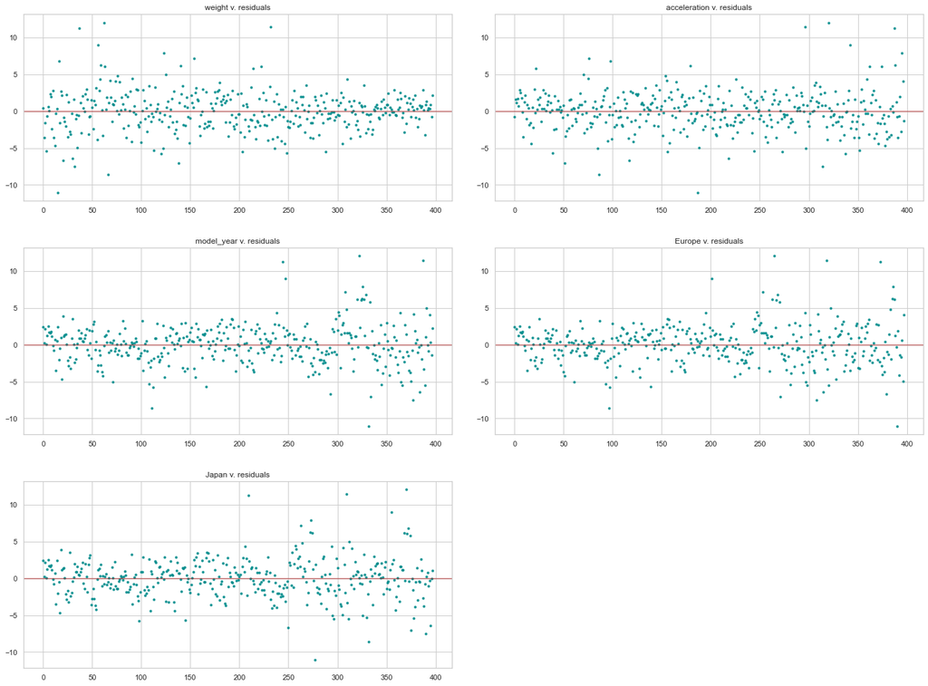

```python
plotResiduals(result6,features2,cars)
```

That seems to have corrected much of the abnormal behavior in our residuals. Let's try one more model to see if there is room for any further improvement.

Back to Top

### Model 7

Perhaps dropping displacement, cylinders, and horsepower was a little too aggressive. Though they are highly correlated, we want to try bringing back just one of them. Cylinders and displacement were the most highly correlated, so choosing one of these would allow us to capture most of the information from the other. Additionally, we had earlier considered the possibility of treating "cylinders" as a categorical. Let's try that now.

```python
if 'cylinders_4' not in cars.columns: #if we re-run this code cell without restarting the whole notebook
    cars = pd.concat([cars, pd.get_dummies(cars["cylinders"], prefix='cylinders')], axis=1)
```

Reminder that we would expect the mpg to decrease as cylinders increase over 4, also bearing in mind that 3 and 5 cylinder cars had a very small sample size. 4 cylinder cars were most common so we choose to keep this feature in our $\beta_0$.

```python
features7 = ['weight_N1_0','acceleration','post69_2_1','Europe','Japan','modern','modern:Europe','modern:Japan',
             'cylinders_3','cylinders_5','cylinders_6','cylinders_8']
result7 = createModel(features7,cars)
models.describe_bootstrap_lr(result7)
```

| Linear Regression Results |  |  |  |
| --- | --- | --- | --- |
| $\theta$ |  | 95% BCI |  |
| ($\beta_0$) | 2.66 | (-1.15, 6.26) |  |
| weight_N1_0 ($\beta_1$) | 48793.23 | (42955.85, 54280.31) |  |
| acceleration ($\beta_2$) | 0.05 | (-0.10, 0.21) |  |
| post69_2_1 ($\beta_3$) | 0.03 | (0.02, 0.04) |  |
| Europe ($\beta_4$) | -0.30 | (-1.43, 0.79) |  |
| Japan ($\beta_5$) | 0.38 | (-0.57, 1.33) |  |
| modern ($\beta_6$) | 0.72 | (-0.61, 1.77) |  |
| modern:Europe ($\beta_7$) | 5.33 | (2.73, 7.47) |  |
| modern:Japan ($\beta_8$) | 2.17 | (0.32, 4.31) |  |
| cylinders_3 ($\beta_9$) | -6.39 | (-8.77, -1.21) |  |
| cylinders_5 ($\beta_10$) | 0.24 | (-3.69, 6.64) |  |
| cylinders_6 ($\beta_11$) | -1.46 | (-2.61, -0.52) |  |
| cylinders_8 ($\beta_12$) | -1.66 | (-3.05, -0.26) |  |
| Metrics |  |  |  |
| $\sigma$ | 2.65 | (2.26, 2.92) |  |
| $R^2$ | 0.89 | (0.87, 0.92) |  |

```python
models.adjusted_r_squared(result7)
```

```
0.8846173409707558
```

We see increases once more in (adjusted) $R^2$ and another decrease in $\sigma$. However, we now see that our Europe coefficient sign (negative) no longer matches our prediction, (positive). We therefore will exclude this from our final model:

Back to Top

### Model 8

```python
features8 = ['weight_N1_0','acceleration','post69_2_1','Japan','modern','modern:Europe','modern:Japan',
             'cylinders_3','cylinders_5','cylinders_6','cylinders_8']
result8 = createModel(features8,cars)
models.describe_bootstrap_lr(result8)
```

| Linear Regression Results |  |  |  |
| --- | --- | --- | --- |
| $\theta$ |  | 95% BCI |  |
| ($\beta_0$) | 2.53 | (-0.39, 6.03) |  |
| weight_N1_0 ($\beta_1$) | 48671.56 | (43485.45, 53637.46) |  |
| acceleration ($\beta_2$) | 0.05 | (-0.11, 0.17) |  |
| post69_2_1 ($\beta_3$) | 0.03 | (0.02, 0.04) |  |
| Japan ($\beta_4$) | 0.52 | (-0.45, 1.38) |  |
| modern ($\beta_5$) | 0.79 | (-0.56, 1.97) |  |
| modern:Europe ($\beta_6$) | 5.08 | (2.91, 6.97) |  |
| modern:Japan ($\beta_7$) | 2.07 | (0.92, 3.74) |  |
| cylinders_3 ($\beta_8$) | -6.38 | (-9.12, -2.68) |  |
| cylinders_5 ($\beta_9$) | 0.17 | (-3.75, 6.88) |  |
| cylinders_6 ($\beta_10$) | -1.37 | (-2.29, -0.48) |  |
| cylinders_8 ($\beta_11$) | -1.54 | (-2.86, -0.43) |  |
| Metrics |  |  |  |
| $\sigma$ | 2.65 | (2.29, 2.91) |  |
| $R^2$ | 0.89 | (0.87, 0.91) |  |

```python
models.adjusted_r_squared(result8)
```

```
0.8848147289765926
```

Dropping this term has given us a very slight increase in our adjusted $R^2$ value. It has also improved the 95% BCI for $\sigma$, though we still see a value of 2.65. Let's take one final look at the residuals.

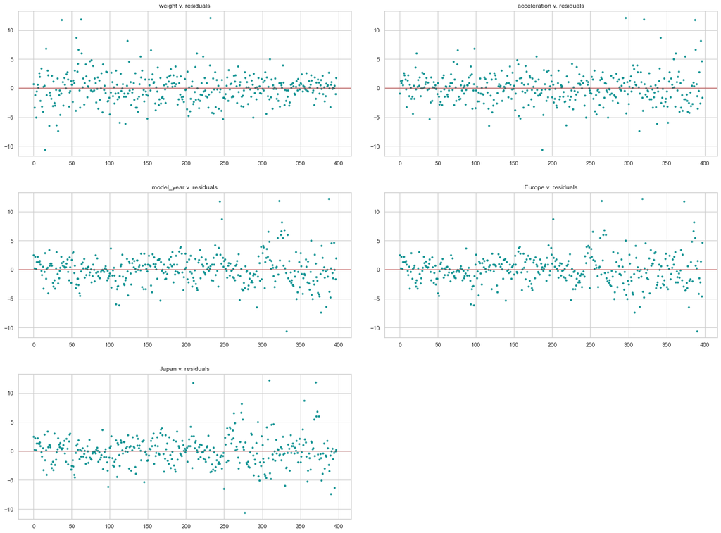

```python
plotResiduals(result8,features2,cars)
```

There is of course always room for fine tuning and improvement, but there do not appear to be any glaring trends left in these values. We shall use this 8th model as our final model.

```python
cars["modern:Europe"] = cars.modern * cars.Europe
cars["modern:Japan"] = cars.modern * cars.Japan
```

Let's take a quick look once more at our correlation matrix to see if we might have reintroduced any multicollinearity with new features.

```python
correlationMatrix(features8)
```

|  | weight_N1_0 | acceleration | post69_2_1 | Japan | modern | modern:Europe | modern:Japan | cylinders_3 | cylinders_5 | cylinders_6 | cylinders_8 |
| --- | --- | --- | --- | --- | --- | --- | --- | --- | --- | --- | --- |
| weight_N1_0 | 1.000000 | 0.382186 | 0.273196 | 0.477500 | 0.238160 | 0.133324 | 0.297138 | 0.057069 | -0.034017 | -0.249498 | -0.701851 |
| acceleration | 0.382186 | 1.000000 | 0.257089 | 0.109144 | 0.202475 | 0.226794 | 0.059948 | -0.084803 | 0.096990 | 0.130516 | -0.560540 |
| post69_2_1 | 0.273196 | 0.257089 | 1.000000 | 0.202312 | 0.871128 | 0.267147 | 0.455961 | -0.019705 | 0.060661 | -0.044378 | -0.327642 |
| Japan | 0.477500 | 0.109144 | 0.202312 | 1.000000 | 0.173485 | -0.111423 | 0.633693 | 0.202471 | -0.043369 | -0.164767 | -0.294053 |
| modern | 0.238160 | 0.202475 | 0.871128 | 0.173485 | 1.000000 | 0.344902 | 0.485775 | -0.010255 | 0.070639 | -0.093088 | -0.245418 |
| modern:Europe | 0.133324 | 0.226794 | 0.267147 | -0.111423 | 0.344902 | 1.000000 | -0.070608 | -0.022560 | 0.252982 | -0.086927 | -0.132302 |
| modern:Japan | 0.297138 | 0.059948 | 0.455961 | 0.633693 | 0.485775 | -0.070608 | 1.000000 | 0.056047 | -0.027483 | -0.098705 | -0.186339 |
| cylinders_3 | 0.057069 | -0.084803 | -0.019705 | 0.202471 | -0.010255 | -0.022560 | 0.056047 | 1.000000 | -0.008781 | -0.052114 | -0.059537 |
| cylinders_5 | -0.034017 | 0.096990 | 0.060661 | -0.043369 | 0.070639 | 0.252982 | -0.027483 | -0.008781 | 1.000000 | -0.045075 | -0.051496 |
| cylinders_6 | -0.249498 | 0.130516 | -0.044378 | -0.164767 | -0.093088 | -0.086927 | -0.098705 | -0.052114 | -0.045075 | 1.000000 | -0.305620 |
| cylinders_8 | -0.701851 | -0.560540 | -0.327642 | -0.294053 | -0.245418 | -0.132302 | -0.186339 | -0.059537 | -0.051496 | -0.305620 | 1.000000 |

```python
# code adapted from course notes

def mean_scale(df, variable):
    x_bar = df[ variable].mean()
    std = df[ variable].std()
    scaled_variable = (df[ variable] - x_bar) / (2.0 * std) # suggested by Gelman
    df[ variable + "_scaled"] = scaled_variable
```

```python
cars = cars.rename(columns={"weight_N1_0":"recip_weight","post69_2_1":"post_1969_raised_2_1"})
mean_scale(cars, "recip_weight")
final_features = ['recip_weight_scaled','acceleration','post_1969_raised_2_1','Japan','modern','modern:Europe','modern:Japan',
             'cylinders_3','cylinders_5','cylinders_6','cylinders_8']
final_result = createModel(final_features,cars)
final_model = final_result['formula']
```

Back to Top

## 1.4 - Describe the model

### Description of Coefficients

Let's take a minute now to describe our final model that we have created.

```python
print(final_model)
```

```
mpg ~ recip_weight_scaled + acceleration + post_1969_raised_2_1 + Japan + modern + modern:Europe + modern:Japan + cylinders_3 + cylinders_5 + cylinders_6 + cylinders_8
```

We see that our model has 11 features. Let's describe these, but first let's start with the intercept, $\beta_0$.

```python
final_result['coefficients']
```

```
array([20.24480377,  9.67887997,  0.04914112,  0.03157387,  0.52397862,
        0.78687452,  5.08335871,  2.07144515, -6.38229553,  0.17378415,
       -1.36701011, -1.53858077])
```

```python
models.describe_bootstrap_lr(final_result)
```

| Linear Regression Results |  |  |  |
| --- | --- | --- | --- |
| $\theta$ |  | 95% BCI |  |
| ($\beta_0$) | 20.24 | (17.84, 23.13) |  |
| recip_weight_scaled ($\beta_1$) | 9.68 | (8.20, 10.65) |  |
| acceleration ($\beta_2$) | 0.05 | (-0.13, 0.20) |  |
| post_1969_raised_2_1 ($\beta_3$) | 0.03 | (0.02, 0.04) |  |
| Japan ($\beta_4$) | 0.52 | (-0.19, 1.62) |  |
| modern ($\beta_5$) | 0.79 | (-0.70, 1.91) |  |
| modern:Europe ($\beta_6$) | 5.08 | (2.77, 7.30) |  |
| modern:Japan ($\beta_7$) | 2.07 | (0.51, 3.78) |  |
| cylinders_3 ($\beta_8$) | -6.38 | (-9.29, -3.73) |  |
| cylinders_5 ($\beta_9$) | 0.17 | (-3.60, 6.76) |  |
| cylinders_6 ($\beta_10$) | -1.37 | (-2.22, -0.45) |  |
| cylinders_8 ($\beta_11$) | -1.54 | (-3.14, -0.47) |  |
| Metrics |  |  |  |
| $\sigma$ | 2.65 | (2.26, 2.92) |  |
| $R^2$ | 0.89 | (0.87, 0.92) |  |

Our next feature is the mean scaled reciprocal of the weight of the car. We see a coefficient of 9.68 and we are quite sure that this value is positive. Taking the reciprocal of the weight means that we now expect a positive coefficient as an increase in this value would actually correspond to a decreased weight. We have also scaled this feature, meaning that every unit increase above the average would result in an extra 9.68 mpg.

Acceleration has a slight positive effect on mpg which is what we predicted after our EDA, but note that 0 falls within the 95% BCI and so this feature is weaker relative to most of our other included features.

The next feature is a little difficult to interpret as well, but we are taking the number of years after 1969 that a car was made, and raising this value to a polynomial of 2.1. A one unit increase here will result in a slight increase (0.03) in our mpg. This makes sense as our prediction is that cars overall become more fuel efficient as time progresses. ALso note that while this effect is weak, we also do not see 0 in our 95% BCI so we are fairly certain it does indeed have a positive effect on mpg.

The next two features are both encoding variables representing whether a car was made in Japan or was made after 1978. We expected both of these features to have a positive effect and they do have positive coefficients, yet note that both of these also contain 0 in their 95% BCI meaning they have relatively weak explanatory value.

The next two variables are interaction variables between "modern" and either Europe or Japan. Both of these features have positive effects on mpg, and 0 is not included in either 95% BCI meaning we can be fairly certain that if a car is both "modern" and from either Europe or Japan then it should have better fuel efficiency relative to our "intercept".

Finally, we have our one hot encoding variables for the number of cylinders in a car, and we chose to leave 4 cylinder cars in the intercept so that we could obtain more accurate base values. Note that 3 and 5 cylinder cars both have very small sample size and so these observations are not very trustworthy. We choose to leave them included so that we can claim that our intercept is a 4 cylinder car. We see negative coefficient values for 6 and 8 cylinder cars meaning that as the number of cylinders of a car increases, the car's fuel efficiency should decrease. 0 is not included in these 95% BCI's, and so we are fairly confident in these effects.

Back to Top

### Cross Validation

Let's evaluate our final model with 3 rounds of 10 fold cross validation.

```python
# code adapted from course notes

def sse(results):
    errors = results['residuals']
    n = len( errors)
    squared_error = np.sum( [e**2 for e in errors])
    return np.sqrt((1.0/n) * squared_error)
```

```python
# code adapted from course notes

def cross_validation(algorithm, formula, data, evaluate=sse, fold_count=10, repetitions=3):
    indices = list(range(len( data)))
    metrics_sse = []
    metrics_r_squared = []
    for _ in range(repetitions):
        random.shuffle(indices)
        folds = chunk(indices, fold_count)
        for fold in folds:
            test_data = data.iloc[fold]
            train_indices = [idx not in fold for idx in indices]
            train_data = data.iloc[train_indices]
            result = algorithm(formula, data=train_data)
            model = result["model"]
            y, X = patsy.dmatrices(formula, test_data, return_type="matrix")
            # y = np.ravel( y) # might need for logistic regression
            results = models.summarize(formula, X, y, model)
            metric_sse = sse(results)
            metric_r_squared = results["r_squared"]

            metrics_sse.append(metric_sse)
            metrics_r_squared.append(metric_r_squared)
    return metrics_sse, metrics_r_squared
```

```python
results_sse, results_r_squared = cross_validation(models.linear_regression, final_model, cars)
len(results_sse)
```

```
30
```

We see that we have 30 results from which we can Bootstrap.

```python
print("Estimate of R Squared after 3 repetitions: ",np.mean(results_r_squared))
print("Estimate of Standard Error after 3 repetitions: ",np.mean(results_sse))
```

```
Estimate of R Squared after 3 repetitions:  0.8825257054789443
Estimate of Standard Error after 3 repetitions:  2.5969154671418258
```

Our estimate of $R^2$ has seemed to decrease very slightly from our original value of 0.89, while the mean of our new $\sigma$ has actually improved from 2.65. Let's see these cross validation results.

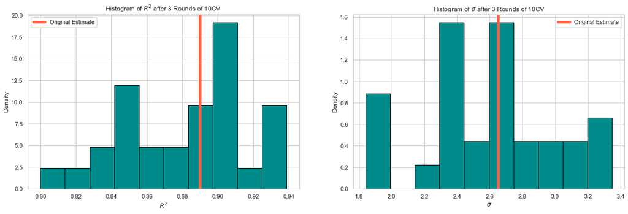

```python
fig, ((ax1, ax2)) = plt.subplots(figsize=(20,6),ncols=2,nrows=1, sharex=False, sharey=False)

ax1.set_xlabel("$R^2$")
ax1.set_ylabel("Density")

ax1.hist(results_r_squared, color=mainColor,ec='black',density=True)
ax1.set_title("Histogram of $R^2$ after 3 Rounds of 10CV")

ax1.axvline(0.89, lw=5, color=secondColor,label="Original Estimate")
ax1.legend()

ax2.set_xlabel("$\sigma$")
ax2.set_ylabel("Density")

ax2.hist(results_sse, color=mainColor,ec='black',density=True)
ax2.set_title("Histogram of $\sigma$ after 3 Rounds of 10CV")

ax2.axvline(2.65, lw=5, color=secondColor,label="Original Estimate")
ax2.legend()

plt.show()
plt.close()
```

The differences in the mean of these distributions vs the original estimate are not immediately clear from these charts. Let's find the 95% Bootstrap estimates for the credible intervals.

```python
# code adapted from course notes

def resample(data):
    n = len(data)
    return [data[ i] for i in [stats.randint.rvs(0, n - 1) for _ in range( 0, n)]]
```

```python
posterior_r_squared = np.array([np.mean(s) for s in [resample(results_r_squared) for i in range( 0,1000)]])
posterior_sse = np.array([np.mean(s) for s in [resample(results_sse) for i in range( 0,1000)]])
```

```python
print(r"95% CI for mean R Squared:", stats.mstats.mquantiles(posterior_r_squared, [0.025, 0.975]))
print(r"95% CI for mean SSE:", stats.mstats.mquantiles(posterior_sse, [0.025, 0.975]))
```

```
95% CI for mean R Squared: [0.8682911  0.89505594]
95% CI for mean SSE: [2.44573508 2.72951717]
```

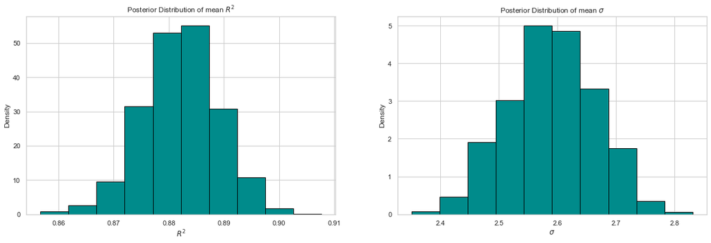

```python
fig, ((ax1, ax2)) = plt.subplots(figsize=(20,6),ncols=2,nrows=1, sharex=False, sharey=False)

ax1.set_xlabel("$R^2$")
ax1.set_ylabel("Density")

ax1.hist(posterior_r_squared, color=mainColor,ec='black',density=True)
ax1.set_title("Posterior Distribution of mean $R^2$")

ax2.set_xlabel("$\sigma$")
ax2.set_ylabel("Density")

ax2.hist(posterior_sse, color=mainColor,ec='black',density=True)
ax2.set_title("Posterior Distribution of mean $\sigma$")

plt.show()
plt.close()
```

These distributions (unsurprisingly) look very much like normal distributions.

Back to Top

### Learning Curves

Let's see if more data would help our model by building some learning curves.

```python
# code adapted from course notes

def learning_curves(algorithm, formula, data, evaluate, fold_count=10, repetitions=3,increment=1):
    indices = list(range(len( data)))
    results = data_collection()
    for _ in range(repetitions):
        random.shuffle(indices)
        folds = chunk(indices, fold_count)
        for fold in folds:
            test_data = data.iloc[ fold]
            train_indices = [idx for idx in indices if idx not in fold]
            train_data = data.iloc[train_indices]
            for i in list(range(increment, 100, increment)) + [100]: # ensures 100% is always picked.
            # the indices are already shuffled so we only need to take ever increasing chunks
                train_chunk_size = int( np.ceil((i/100)*len( train_indices)))
                train_data_chunk = data.iloc[train_indices[0:train_chunk_size]]
                # we calculate the model
                result = algorithm(formula, data=train_data_chunk)
                model = result["model"]
                # we calculate the results for the training data subset
                y, X = patsy.dmatrices( formula, train_data_chunk, return_type="matrix")
                result = models.summarize(formula, X, y, model)
                metric = evaluate(result)
                results["train"][i].append( metric)
                # we calculate the results for the test data.
                y, X = patsy.dmatrices( formula, test_data, return_type="matrix")
                result = models.summarize(formula, X, y, model)
                metric = evaluate(result)
                results["test"][i].append( metric)
    #
    #
    # process results
    # Rely on the CLT...
    statistics = {}
    for k, v in results["train"].items():
        statistics[ k] = (np.mean(v), np.std(v))
    results["train"] = statistics
    statistics = {}
    for k, v in results["test"].items():
        statistics[ k] = (np.mean(v), np.std(v))
    results["test"] = statistics
    return results
```

```python
# code adapted from course notes

def plot_learning_curves( results, metric, desired=None, zoom=False, credible=True):
    figure = plt.figure(figsize=(10,6))
    axes = figure.add_subplot(1, 1, 1)
    xs, train_lower, train_mean, train_upper = results_to_curves( "train", results)
    _, test_lower, test_mean, test_upper = results_to_curves( "test", results)
    axes.plot( xs, train_mean, color="steelblue", label="train")
    axes.plot( xs, test_mean, color="firebrick", label="test")

    if credible:
        axes.fill_between( xs, train_upper, train_lower, color="steelblue", alpha=0.25)
        axes.fill_between( xs, test_upper, test_lower, color="firebrick", alpha=0.25)
    if desired:
        if type(desired) is tuple:
            axes.axhline((desired[0] + desired[1])/2.0, color="gold", label="desired")
            axes.fill_between( xs, desired[1], desired[0], color="gold", alpha=0.25)
        else:
            axes.axhline( desired, color="gold", label="desired")

    axes.legend()
    axes.set_xlabel( "training set (%)")
    axes.set_ylabel( metric)
    axes.set_title("Learning Curves")
    if zoom:
        y_lower = int( 0.9 * np.amin([train_lower[-1], test_lower[-1]]))
        y_upper = int( 1.1 * np.amax([train_upper[-1], test_upper[-1]]))
        axes.set_ylim((y_lower, y_upper))
    plt.show()
    plt.close()
```

```python
curveResults = learning_curves(models.linear_regression, final_model, cars, sse, increment=5)
```

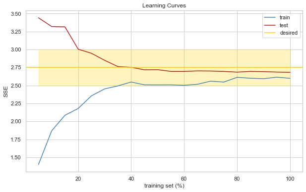

```python
plot_learning_curves(curveResults, r"SSE", desired=(2.5, 3), credible=False)
```

Between about 20-40% of our training set size we see our train and test curves begin to converge. This indicates that we are in a relatively high bias scenario and if we wanted to further improve our final model, gathering more data would be unlikely to help.

Back to Top

## 1.5 - Use the model

Let's now use our final model to predict some values. For example, right now we shall simply examine the first entry in our dataset.

```python
pd.DataFrame(cars[["recip_weight_scaled","acceleration","post_1969_raised_2_1","Japan","modern","modern:Europe","modern:Japan",
                   "cylinders_3","cylinders_5","cylinders_6","cylinders_8"]].iloc[0]).transpose()
```

|  | recip_weight_scaled | acceleration | post_1969_raised_2_1 | Japan | modern | modern:Europe | modern:Japan | cylinders_3 | cylinders_5 | cylinders_6 | cylinders_8 |
| --- | --- | --- | --- | --- | --- | --- | --- | --- | --- | --- | --- |
| 0 | -0.395162 | 12.0 | 1.0 | 0.0 | 0.0 | 0.0 | 0.0 | 0.0 | 0.0 | 0.0 | 1.0 |

As a reminder, we must explicitly pass "1" as our first value in the array for our intercept.

```python
predictedMPG = final_result["model"].predict(np.array([[1, -0.395162, 12, 1, 0, 0, 0, 0, 0, 0, 0, 1]]))[0][0]
predictedMPG
```

```
15.502764796605067
```

So we have a predicted value of 15.50 mpg for our first car. What is the true value?

```python
actualMPG = cars.mpg[0]
actualMPG
```

```
18.0
```

So we see a bit of an error in our first estimate. How many standard deviations is that?

```python
abs(actualMPG - predictedMPG)/final_result["sigma"]
```

```
0.9438551186160951
```

So our first entry happens to be less than one standard deviation away from the true value. If all of our values were normally distributed, we would expect the errors to be with one standard deviation 68% of the time and within two 95% of the time. What is our 95% bounds on our estimate?

```python
print("({0:.2f}, {1:.2f})".format(predictedMPG - 2 * final_result["sigma"], predictedMPG + 2 * final_result["sigma"]))
```

```
(10.21, 20.79)
```

95% of the time we would expect a car with attributes like our first car to have an mpg between 10.21 and 20.79. What if we had no information about these features at all?

```python
mean_mpg = cars.mpg.mean()
std_mpg = cars.mpg.std()
print("({0:.2f}, {1:.2f})".format(mean_mpg - 2 * std_mpg, mean_mpg + 2* std_mpg))
```

```
(7.88, 39.15)
```

We saw earlier that mpg was not quite normally distributed, so the above bounds are not quite 95% intervals. By looking at 2 standard deviations from the mean, Chebyshev's inequality tells us that we can be guaranteed that just 75% of the values for mpg will fall within a range of 7.88 and 39.15. Even if we could claim that mpg were normally distributed, this 95% bound would still be far larger than what we obtain using our final model. Let's now check to see if indeed are our errors are normally distributed.

```python
errors = []
for index in range(len(cars)):
    features_array = [1]
    for feature in final_features:
        features_array.append(cars[feature].iloc[index])
    predicted_MPG = final_result["model"].predict(np.array([features_array]))[0][0]
    actual_MPG = cars.mpg[index]
    errors.append(predicted_MPG - actual_MPG)
```

Above we have calculated the errors between the prediction our model gives and the actual value. Below we visualize these results.

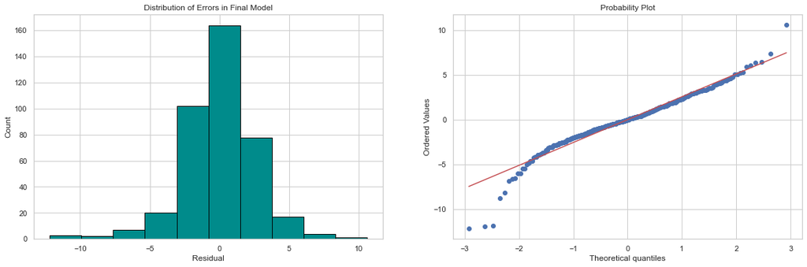

```python
fig, ((ax1, ax2)) = plt.subplots(figsize=(20,6),ncols=2,nrows=1, sharex=False, sharey=False)

ax1.set_xlabel("Residual")
ax1.set_ylabel("Count")

ax1.hist(errors, color=mainColor, ec='black',density=False)
ax1.set_title("Distribution of Errors in Final Model")

stats.probplot(errors, dist="norm", plot=ax2)

plt.show()
plt.close()
```

The normal distribution appears to be a good approximation for our predicted errors.

Back to Top

**CHECK LIST**

Before you submit this assignent, go back and review the directions to ensure that you have followed each instruction.

- Have you completed every section and answered every question asked?
- For every question, have you described your approach and explained your results?
- Have you checked for spelling and grammar errors?
- Are your code blocks free of any errors?
- Have you *SAVED* your notebook?